# PROJET

### Analyse

Analyse du modèle de régression linéaire : Mortalité avec VIH vs Prévalence Résumé des résultats :

Résidus :

Min : -165.638

1er quartile : -10.022

Médiane : 1.190

3ème quartile : 5.056

Max : 284.697

Les résidus montrent une certaine dispersion autour de zéro, ce qui suggère qu’il y a une variabilité dans les erreurs de prédiction. Cependant, il n’y a pas de biais systématique important. Les valeurs extrêmes (maximum et minimum) pourraient indiquer la présence de quelques outliers, mais dans l’ensemble, les résidus semblent relativement bien répartis.

Relation entre les variables :

La mortalité due à la tuberculose chez les personnes vivant avec le VIH est positivement liée à la prévalence de la tuberculose (toutes formes). Cela signifie que, lorsque la prévalence augmente, la mortalité chez les personnes vivant avec le VIH tend également à augmenter.

Interprétation des coefficients :

Intercept : -6.41809, ce qui signifie que lorsque la prévalence de la tuberculose est nulle, la mortalité due à la tuberculose chez les personnes vivant avec le VIH serait de -6.42 (valeur théorique, mais pas réaliste dans ce contexte).

Coefficient de la prévalence : 0.10669, ce qui signifie qu’une augmentation de 1 décès par 100 000 habitants dans la prévalence de la tuberculose est associée à une augmentation de 0.10669 décès par 100 000 habitants pour la mortalité de la tuberculose chez les personnes vivant avec le VIH.

Significativité :

Le p-value pour le coefficient de la prévalence de la tuberculose est < 2e-16, ce qui signifie que la relation entre la prévalence et la mortalité avec VIH est hautement significative.

Le p-value de l’intercept est de 0.112, ce qui suggère que l’intercept n’est pas très significatif (mais il sert de point de départ pour la relation linéaire).

R-squared (R²) :

R-squared = 0.2922, ce qui signifie que 29.22% de la variance dans la mortalité de la tuberculose chez les personnes vivant avec le VIH est expliquée par la prévalence de la tuberculose. Bien que cela montre une certaine relation, il reste encore une grande part de la variabilité qui n’est pas expliquée par ce modèle, suggérant que d’autres facteurs pourraient influencer la mortalité avec VIH.

Adjusted R-squared = 0.2888, indiquant que l’ajustement du modèle reste faible même après correction pour le nombre de variables.

F-statistic :

F-statistic = 86.69 avec une p-value très faible (< 2.2e-16), ce qui indique que le modèle global est significatif. Cela suggère que la relation entre la prévalence et la mortalité avec VIH est robuste.

Conclusion : Le modèle montre que la prévalence de la tuberculose (toutes formes) est un prédicteur significatif de la mortalité de la tuberculose chez les personnes vivant avec le VIH. Cependant, seulement 29.22% de la variance dans la mortalité avec VIH est expliquée par ce modèle, ce qui indique qu’il existe d’autres facteurs non inclus dans le modèle qui influencent cette relation.

La relation est statistiquement significative (p-value très faible), mais l’ajustement global du modèle pourrait être amélioré, car une grande partie de la variance reste inexpliquée. Des variables supplémentaires pourraient être prises en compte pour renforcer l’ajustement du modèle.

##résidus versus valeurs ajustées

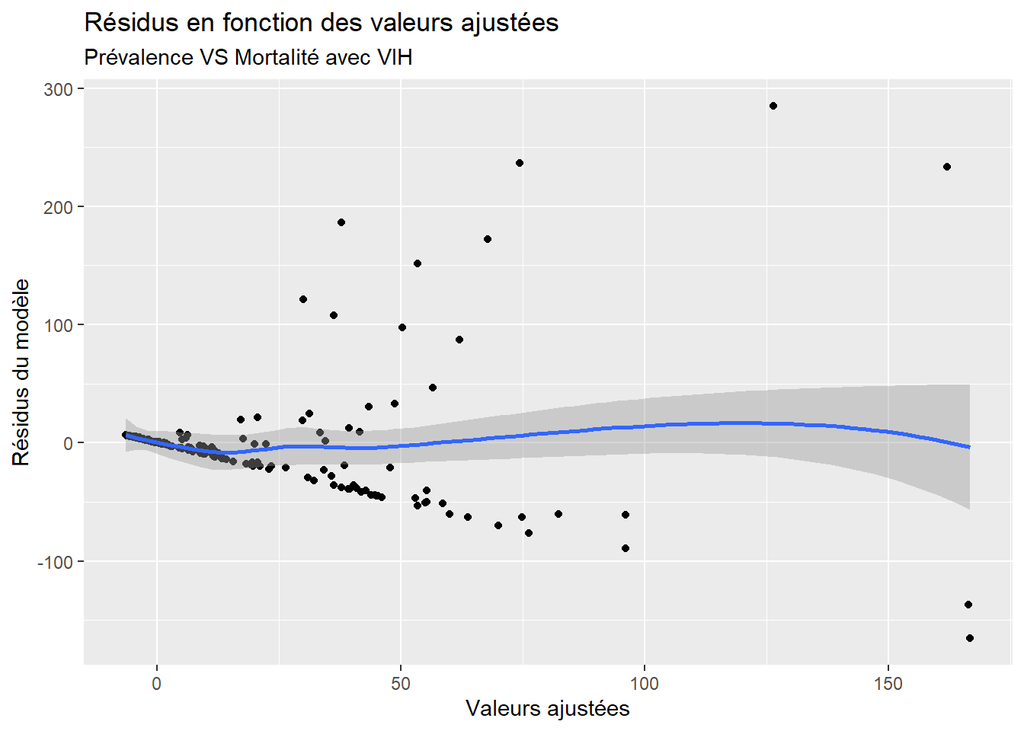

```r
ggplot() +
  aes(x = fitted(mortalite_avec_vih_vs_prevalance ), y = residuals(mortalite_avec_vih_vs_prevalance )) +
  geom_point() +  # Nuage de points
  geom_smooth() +
  xlab("Valeurs ajustées") +
  ylab("Résidus du modèle") +
  ggtitle("Résidus en fonction des valeurs ajustées", subtitle = "Prévalence VS Mortalité avec VIH")
```

### ANALYSE

La courbe lissée (geom_smooth) indique une forme non linéaire des résidus par rapport aux valeurs ajustées. Cela suggère qu’un modèle linéaire ne s’adapte pas parfaitement aux données, car les erreurs de prédiction ne sont pas distribuées de manière homogène à travers les différentes valeurs ajustées.

##qqplot

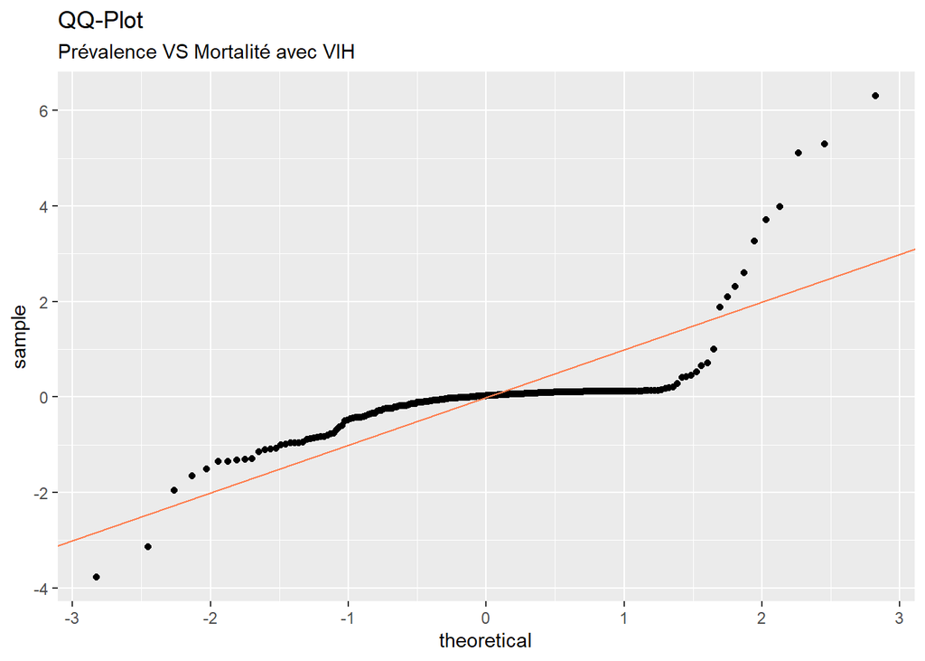

```r
ggplot() +
  geom_qq(aes(sample=rstandard(mortalite_avec_vih_vs_prevalance )))+
  geom_abline(color="coral")+
  ggtitle("QQ-Plot", subtitle="Prévalence VS Mortalité avec VIH")
```

### Analyse :

Le QQ-plot montre la distribution des résidus de notre modèle de régression par rapport à une distribution normale théorique.

Analyse du graphique : Axe théorique : Il représente les quantiles de la distribution normale théorique.

Axe des échantillons (sample) : Il représente les quantiles des résidus standardisés de votre modèle.

Écarts aux extrémités : Les points commencent à s’éloigner de la droite aux extrémités (dans les valeurs négatives et positives élevées), ce qui suggère que les résidus présentent des queues plus lourdes que ce qui serait attendu d’une distribution normale. Cela pourrait indiquer une asymétrie ou la présence de valeurs extrêmes.

Ainsi, le QQ-plot suggère que les résidus de la régression sont relativement normaux, mais qu’il y a des outliers ou des écarts dans les queues de la distribution, ce qui pourrait influencer les résultats de vos tests statistiques. Il pourrait être utile de traiter ces points extrêmes ou d’explorer des modèles robustes pour gérer ces anomalies.

##scale-location (position-échelle)

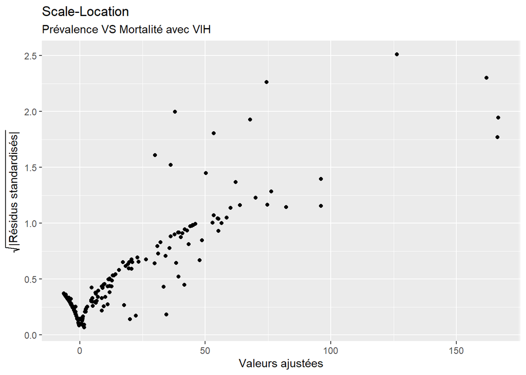

```r
ggplot() +
  aes(x = fitted(mortalite_avec_vih_vs_prevalance), y = sqrt(abs(rstandard(mortalite_avec_vih_vs_prevalance)))) +
  geom_point()  +
  xlab("Valeurs ajustées") +
  ylab(expression(sqrt("|Résidus standardisés|"))) +
  ggtitle("Scale-Location", subtitle="Prévalence VS Mortalité avec VIH")
```

### Analyse

Ce graphique montre la relation entre les valeurs ajustées (prédictions du modèle) et les résidus standardisés (échelles transformées par la racine carrée des résidus absolus). Cela permet d’examiner si l’hypothèse d’homoscédasticité (variance constante des résidus) est respectée.

1. Description du graphique :

Axe X : Les valeurs ajustées (c’est-à-dire les prédictions du modèle pour chaque observation).

Axe Y : Les résidus standardisés, transformés par la racine carrée de la valeur absolue des résidus. Cela permet de mieux visualiser la dispersion des résidus.

2. Interprétation du graphique :

3. Conclusion :

## distance de cook

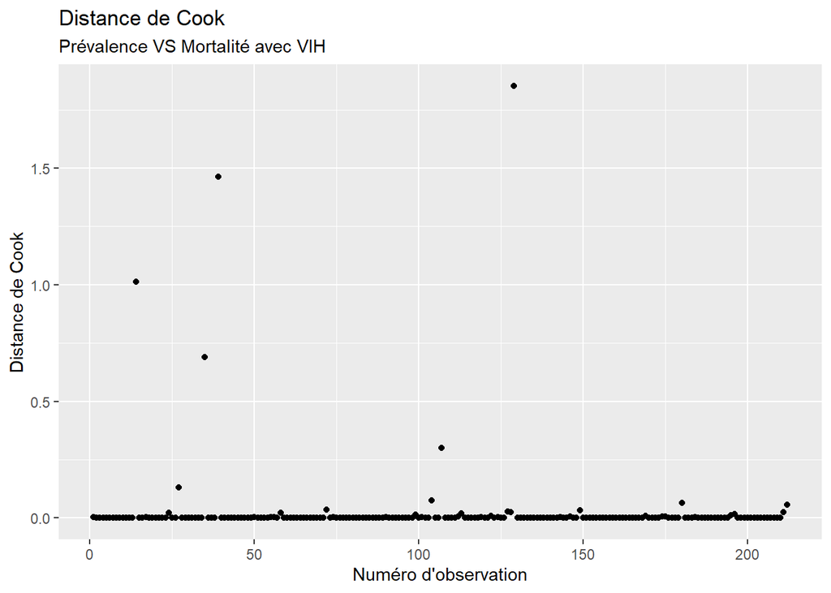

```r
ggplot() +
  aes(x =seq_along(cooks.distance(mortalite_avec_vih_vs_prevalance)), y = cooks.distance(mortalite_avec_vih_vs_prevalance)) +
  geom_point()  +
  xlab("Numéro d'observation") +
  ylab("Distance de Cook") +
  ggtitle("Distance de Cook", subtitle="Prévalence VS Mortalité avec VIH")
```

### Analyse :

Ce graphique montre la distance de Cook pour chaque observation dans le modèle de régression, ce qui permet d’identifier les observations qui ont une influence excessive sur les coefficients du modèle.

1. Description du graphique :

Axe X : Le numéro d’observation, c’est-à-dire l’identifiant de chaque individu dans le jeu de données.

Axe Y : La distance de Cook, qui mesure l’influence de chaque observation sur le modèle. Plus cette distance est grande, plus l’observation a un impact important sur les paramètres du modèle.

2. Interprétation du graphique :

La plupart des observations ont une distance de Cook très faible, ce qui indique qu’elles n’ont pas une influence excessive sur le modèle. Cependant, quelques points (principalement situés entre les premières 50 observations) ont des distances de Cook relativement élevées, suggérant que ces observations ont un impact plus important sur le modèle. Ces points pourraient être des outliers ou des points influents qui méritent d’être examinés de plus près.

3. Conclusion :

Le graphique suggère qu’une petite fraction des observations ont une influence significative sur le modèle. Ces points pourraient être des outliers ou des observations particulières qui doivent être vérifiées plus attentivement.

Si ces points influents sont des erreurs de saisie ou des anomalies, leur exclusion ou leur traitement pourrait améliorer l’ajustement du modèle.

En résumé, bien que la plupart des observations n’aient pas une influence majeure, il serait prudent de vérifier les points avec des distances de Cook élevées pour comprendre pourquoi elles ont une telle influence et décider si elles doivent être exclues ou traitées différemment.

##residual versus leverage

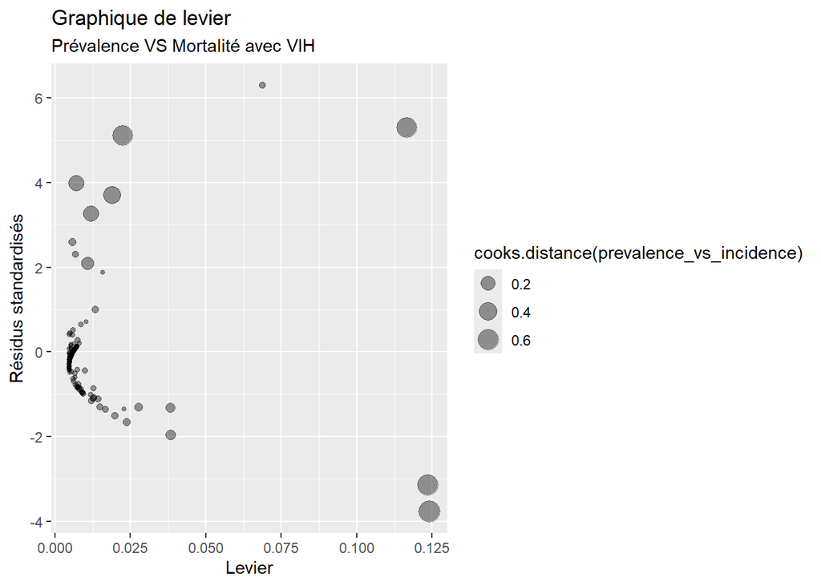

```r
ggplot() +
  aes(x =hatvalues(mortalite_avec_vih_vs_prevalance), y = rstandard(mortalite_avec_vih_vs_prevalance)) +
  geom_point(aes(size=cooks.distance(prevalence_vs_incidence)),alpha=0.4)  +
  xlab("Levier") +
  ylab("Résidus standardisés") +
  ggtitle("Graphique de levier", subtitle="Prévalence VS Mortalité avec VIH")
```

### Analyse

Ce graphique examine la relation entre les résidus standardisés et le levier des observations dans le modèle de régression, tout en tenant compte de la distance de Cook. Il permet de détecter les points influents, à la fois en termes d’impact sur la régression (résidus) et de leur influence sur le modèle (levier).

1. Description du graphique :

Axe X (Levier) : Le levier mesure l’influence potentielle d’une observation sur les valeurs ajustées du modèle. Un levier élevé indique qu’une observation est éloignée de la moyenne des autres observations.

Axe Y (Résidus standardisés) : Les résidus standardisés mesurent l’écart entre les valeurs observées et les valeurs ajustées, normalisées pour tenir compte de la variance des erreurs.

2. Interprétation du graphique :

Les points avec un levier élevé sont plus éloignés de la droite de régression, ce qui signifie qu’ils ont une forte capacité à influencer les résultats du modèle.

En revanche, la majorité des points se trouvent près de l’axe des résidus (proches de zéro), indiquant que la plupart des observations ont une faible influence sur le modèle.

3. Conclusion :

Les points influents (grands cercles) doivent être examinés plus attentivement. Si ces points sont des outliers ou des observations extrêmes, ils pourraient avoir un impact disproportionné sur les résultats du modèle.

Un levier élevé combiné à un résidu important indique qu’une observation a une influence significative sur le modèle, et ces observations doivent être vérifiées pour décider si elles doivent être exclues ou traitées différemment.

En résumé, ce graphique identifie les points influents qui peuvent nécessiter une attention particulière avant d’interpréter pleinement les résultats du modèle . ———————————————————————- ##II.1.4) prévalence & mortalité sans vih

##nuage de points

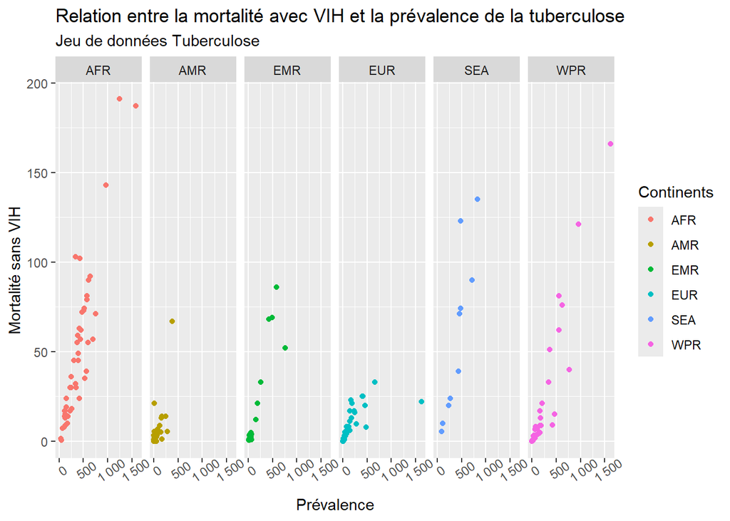

```r
ggplot(TB2_2000)+
  aes(x= `Estimated_prevalence_of_TB_(all_forms)_per_100_000_population`,
      y=`Estimated_mortality_of_TB_cases_(all_forms,_excluding_HIV)_per_100_000_population`,
      colour= Region)+
  geom_point()+
  labs(
    x="Prévalence",
    y="Mortalité sans VIH",
    colour="Continents"
  )+
  ggtitle("Relation entre la mortalité avec VIH et la prévalence de la tuberculose",
          subtitle = "Jeu de données Tuberculose")+
  scale_x_continuous(labels = scales::label_number(decimal.mark=","))+
  scale_y_continuous(
    labels = scales::label_number(decimal.mark=",")
  )+
  facet_grid(cols=vars(Region))+
  theme(axis.text.x=element_text(angle=35))
```

### Analyse

Nuage de points : Prévalence vs Mortalités sans VIH 1. Description du graphique :

Axe X (Prévalence) : La prévalence de la tuberculose par 100 000 habitants.

Axe Y (Mortalité sans VIH) : La mortalité de la tuberculose (toutes formes) excluant les cas VIH par 100 000 habitants.

Couleur des points : Chaque continent est représenté par une couleur différente. Les couleurs permettent de distinguer les continents de manière claire.

Facettes : Le graphique est subdivisé en facettes, chaque facette représentant un continent. Cela permet une analyse comparée entre les continents.

2. Interprétation du graphique :

Relation entre prévalence et mortalité : En observant le graphique, on remarque une tendance générale qui suggère que dans la plupart des continents, une prévalence plus élevée semble être associée à une mortalité plus élevée.

Disparité entre les continents :

Par exemple, l’Afrique (représentée en rouge) montre une plus grande dispersion des points, indiquant que la relation entre la prévalence et la mortalité n’est pas linéaire dans cette région. Cela pourrait être dû à des facteurs socio-économiques variés, des systèmes de santé différents ou des méthodes de diagnostic diverses.

D’autres continents, comme l’Europe (en bleu), affichent des points plus concentrés et une relation qui semble plus linéaire, suggérant une meilleure gestion ou un suivi plus systématique des cas de tuberculose.

3. Conclusion : Le graphique montre qu’il existe une tendance générale où la prévalence et la mortalité sont liées, mais cette relation varie d’un continent à l’autre. Les différences observées entre les continents peuvent être dues à des facteurs socio-économiques, des politiques de santé, des systèmes de soins ou des pratiques de diagnostic qui diffèrent d’une région à l’autre.

En résumé, bien que la prévalence et la mortalité de la tuberculose soient généralement liées, la force de cette relation varie selon les continents, suggérant que des facteurs externes jouent un rôle important dans l’incidence et la mortalité de la tuberculose.

## covariance

```r
TB2_2000 %>% select(`Estimated_prevalence_of_TB_(all_forms)_per_100_000_population`,
`Estimated_mortality_of_TB_cases_(all_forms,_excluding_HIV)_per_100_000_population`)%>%cov()
```

```
##                                                                                   Estimated_prevalence_of_TB_(all_forms)_per_100_000_population
## Estimated_prevalence_of_TB_(all_forms)_per_100_000_population                                                                         79120.657
## Estimated_mortality_of_TB_cases_(all_forms,_excluding_HIV)_per_100_000_population                                                      8370.268
##                                                                                   Estimated_mortality_of_TB_cases_(all_forms,_excluding_HIV)_per_100_000_population
## Estimated_prevalence_of_TB_(all_forms)_per_100_000_population                                                                                              8370.268
## Estimated_mortality_of_TB_cases_(all_forms,_excluding_HIV)_per_100_000_population                                                                          1208.579
```

### Analyse

Covariance de la prévalence avec elle-même : 79,120.66 La covariance d’une variable avec elle-même est égale à la variance de cette variable. Cela montre à quel point les valeurs de la prévalence varient par rapport à leur moyenne. Une variance élevée de la prévalence suggère que les valeurs de prévalence sont largement dispersées.

Covariance entre la prévalence et la mortalité (toutes formes, excluant VIH) : 8,370.27 La covariance entre la prévalence et la mortalité est positive. Cela indique qu’il existe une relation positive entre les deux variables : lorsque la prévalence de la tuberculose augmente, la mortalité (hors VIH) tend également à augmenter. Cela confirme une tendance générale selon laquelle plus il y a de cas de tuberculose dans une population, plus le nombre de décès associés est élevé.

Covariance de la mortalité avec elle-même (toutes formes, excluant VIH) : 1,208.58 La covariance de la mortalité avec elle-même est également une mesure de la variance de cette variable. Elle donne une idée de la dispersion des valeurs de mortalité autour de leur moyenne. Cette valeur est relativement plus faible que celle de la prévalence, ce qui indique que la mortalité est moins dispersée que la prévalence.

Conclusion : La covariance positive entre la prévalence et la mortalité (hors VIH) de 8,370.27 montre qu’une augmentation de la prévalence est généralement associée à une augmentation de la mortalité. Cependant, comme la covariance est influencée par les unités de mesure des variables, pour évaluer la force et l’intensité de cette relation de manière plus fiable, il serait préférable de calculer des mesures normalisées telles que le coefficient de corrélation.

##coefficient de corrélation pearson

```r
cor(x=TB2_2000[["Estimated_prevalence_of_TB_(all_forms)_per_100_000_population"]], y=TB2_2000[["Estimated_mortality_of_TB_cases_(all_forms,_excluding_HIV)_per_100_000_population"]], method ="pearson")
```

```
## [1] 0.8559669
```

##coefficient de corrélation Spearman

```r
cor(x=TB2_2000[["Estimated_prevalence_of_TB_(all_forms)_per_100_000_population"]], y=TB2_2000[["Estimated_mortality_of_TB_cases_(all_forms,_excluding_HIV)_per_100_000_population"]], method ="spearman")
```

```
## [1] 0.9274942
```

### Analyse

Interprétation des coefficients de corrélation : Coefficient de corrélation de Pearson : 0.856 Un coefficient de 0.856 indique une relation forte et linéaire positive entre la prévalence de la tuberculose et la mortalité de la tuberculose (toutes formes, excluant VIH). Cela signifie qu’à mesure que la prévalence augmente, la mortalité associée augmente de manière relativement linéaire. La valeur proche de 1 suggère que la relation linéaire entre ces deux variables est bien définie et significative.

Coefficient de corrélation de Spearman : 0.927 Un coefficient de 0.927 pour Spearman indique une relation monotone très forte entre la prévalence et la mortalité. Cela signifie que, bien que la relation ne soit pas nécessairement linéaire, il existe une tendance claire où, à mesure que la prévalence augmente, la mortalité a tendance à augmenter aussi. Ce coefficient est légèrement plus élevé que celui de Pearson, ce qui montre que même si la relation n’est pas strictement linéaire, elle est encore extrêmement forte.

Conclusion : Pearson (0.856) montre une forte relation linéaire entre la prévalence et la mortalité, ce qui indique qu’une augmentation de la prévalence est associée à une augmentation linéaire de la mortalité. Cela renforce l’idée que les deux variables sont étroitement liées.

Spearman (0.927) montre une relation monotone encore plus forte, ce qui signifie que, bien que la relation puisse ne pas être parfaitement linéaire, les deux variables évoluent dans la même direction de manière générale.

Dans les deux cas, la prévalence et la mortalité sont fortement corrélées, avec Spearman indiquant une relation particulièrement robuste en termes de monotonie.

##regression linéaire

```r
mortalite_sans_vih_vs_prevalance <-TB2_2000%>% lm(`Estimated_mortality_of_TB_cases_(all_forms,_excluding_HIV)_per_100_000_population` ~
                               `Estimated_prevalence_of_TB_(all_forms)_per_100_000_population`,
                             data =.)

# Résumé du modèle
summary(mortalite_sans_vih_vs_prevalance)
```

```
##
## Call:
## lm(formula = `Estimated_mortality_of_TB_cases_(all_forms,_excluding_HIV)_per_100_000_population` ~
##     `Estimated_prevalence_of_TB_(all_forms)_per_100_000_population`,
##     data = .)
##
## Residuals:
##      Min       1Q   Median       3Q      Max
## -149.365   -3.705   -0.706    0.900   72.660
##
## Coefficients:
##                                                                 Estimate
## (Intercept)                                                     -0.33433
## `Estimated_prevalence_of_TB_(all_forms)_per_100_000_population`  0.10579
##                                                                 Std. Error
## (Intercept)                                                        1.54896
## `Estimated_prevalence_of_TB_(all_forms)_per_100_000_population`    0.00441
##                                                                 t value
## (Intercept)                                                      -0.216
## `Estimated_prevalence_of_TB_(all_forms)_per_100_000_population`  23.991
##                                                                 Pr(>|t|)
## (Intercept)                                                        0.829
## `Estimated_prevalence_of_TB_(all_forms)_per_100_000_population`   <2e-16 ***
## ---
## Signif. codes:  0 '***' 0.001 '**' 0.01 '*' 0.05 '.' 0.1 ' ' 1
##
## Residual standard error: 18.02 on 210 degrees of freedom
## Multiple R-squared:  0.7327, Adjusted R-squared:  0.7314
## F-statistic: 575.6 on 1 and 210 DF,  p-value: < 2.2e-16
```

### Analyse :

Les résidus représentent la différence entre les valeurs observées et les valeurs ajustées (prédictions) par le modèle.

Le minimum des résidus est de -149.365, ce qui montre qu’il y a des erreurs de prédiction assez importantes dans certaines observations.

Le 1er quartile est de -3.705, la médiane est de -0.706, et le 3ème quartile est de 0.900. Cela montre que la majorité des erreurs de prédiction sont relativement faibles et proches de zéro.

Le maximum est de 72.660, ce qui indique qu’il existe des erreurs de prédiction assez importantes dans certaines observations (outliers possibles).

On peut conclure que les résidus sont relativement éparpillés, ce qui montre qu’il y a une variabilité dans les erreurs de prédiction. Cependant, cette dispersion ne semble pas être excessivement biaisée, car la médiane est proche de zéro et la majorité des valeurs se trouvent autour de zéro. Cela suggère que le modèle est relativement bien ajusté, même si des points influents ou des outliers existent.

La mortalité de la tuberculose (toutes formes, excluant VIH) est positivement liée à la prévalence de la tuberculose (toutes formes). Pour chaque augmentation de 1 décès par 100 000 habitants dans la prévalence de la tuberculose, la mortalité de la tuberculose (excluant le VIH) augmente de 0.10579 décès par 100 000 habitants.

R-squared : Le modèle explique 73.27% de la variance dans la mortalité de la tuberculose (excluant le VIH), ce qui montre que la prévalence est un facteur très important pour prédire la mortalité dans ce modèle.

F-statistic : Le F-statistic est élevé (575.6) avec une p-value très faible (< 2.2e-16), indiquant que le modèle est globalement significatif et que la relation entre les deux variables est robuste.

Conclusion : La prévalence de la tuberculose (toutes formes) est un prédicteur significatif de la mortalité de la tuberculose (excluant le VIH) dans la population générale, avec un modèle qui explique 73.27% de la variance de la mortalité. La relation entre ces deux variables est forte et significative.

##résidus versus valeurs ajustées

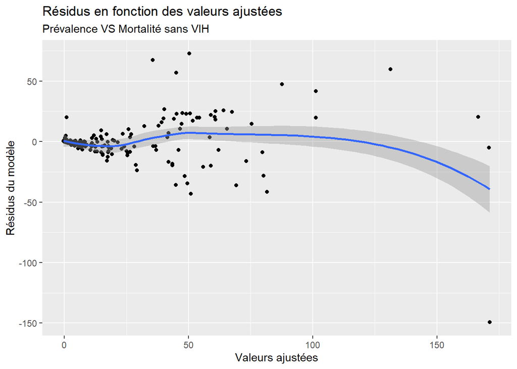

```r
ggplot() +
  aes(x = fitted(mortalite_sans_vih_vs_prevalance ), y = residuals(mortalite_sans_vih_vs_prevalance )) +
  geom_point() +  # Nuage de points
  geom_smooth() +
  xlab("Valeurs ajustées") +
  ylab("Résidus du modèle") +
  ggtitle("Résidus en fonction des valeurs ajustées", subtitle = "Prévalence VS Mortalité sans VIH")
```

### Analyse

Le graphique que vous avez partagé représente les résidus en fonction des valeurs ajustées (prédictions du modèle de régression), dans le cadre de l’analyse de la relation entre la prévalence et la mortalité sans VIH.

Interprétation : Comportement des résidus :

Variation de la variabilité :

Forme non linéaire :

La courbe lissée (en bleu) indique que les résidus ne sont pas distribués de manière homogène par rapport aux valeurs ajustées. Cette courbe a une forme non linéaire, ce qui suggère que les erreurs de prédiction ne suivent pas une distribution constante à travers toutes les valeurs ajustées. Cela pourrait indiquer que le modèle linéaire ne capture pas toute la dynamique des données.

Hétéroscédasticité :

##qqplot

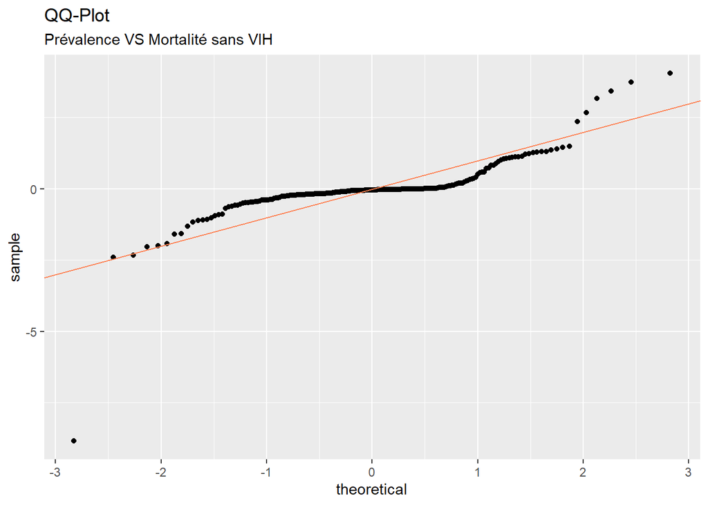

```r
ggplot() +
  geom_qq(aes(sample=rstandard(mortalite_sans_vih_vs_prevalance)))+
  geom_abline(color="coral")+
  ggtitle("QQ-Plot", subtitle="Prévalence VS Mortalité sans VIH")
```

### Analyse Le graphique que vous avez partagé représente un QQ-plot des résidus de votre modèle de régression, comparés à une distribution normale théorique.

Interprétation du QQ-plot : Alignement des points :

Écarts aux extrémités :

Cependant, les points commencent à s’éloigner de la droite aux extrémités (c’est-à-dire dans les valeurs négatives et positives élevées), ce qui suggère que les queues de la distribution des résidus sont plus lourdes que ce que l’on attendrait d’une distribution normale. Cela peut indiquer une asymétrie ou la présence de valeurs extrêmes (outliers).

Impact des outliers et des queues lourdes :

Les écarts aux extrémités peuvent avoir un impact important sur les tests statistiques. Des valeurs extrêmes peuvent déformer l’ajustement du modèle et influencer la significativité des résultats. Il peut être utile d’examiner ces outliers plus attentivement.

Conclusion : Le QQ-plot suggère que les résidus de la régression suivent une distribution normale dans l’ensemble, mais les outliers et les queues lourdes indiquent qu’il pourrait y avoir des anomalies qui influencent les résultats du modèle. Il serait pertinent d’examiner de plus près ces points extrêmes, voire d’explorer des modèles robustes pour mieux gérer ces anomalies.

##scale-location (position-échelle)

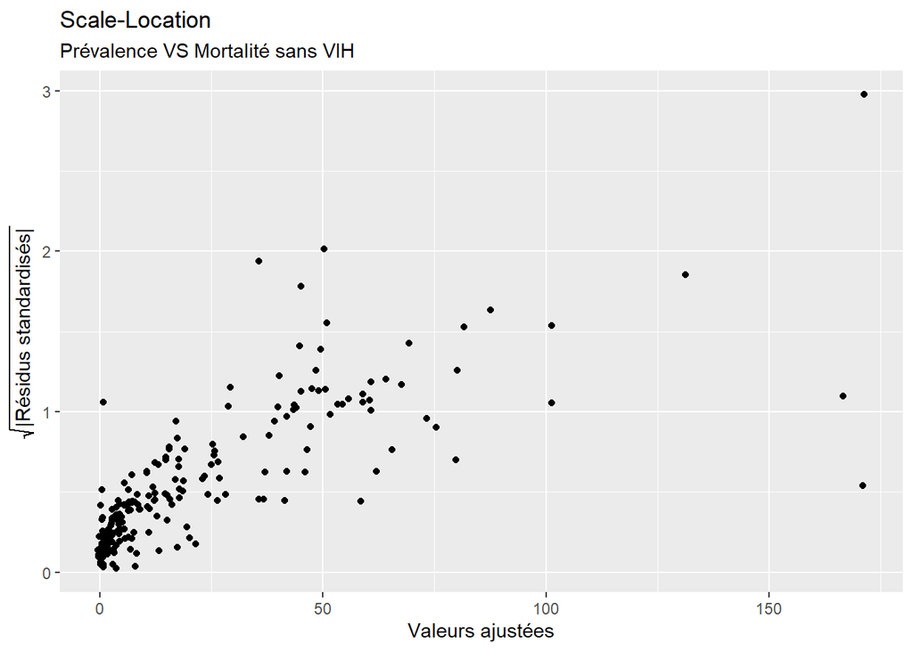

```r
ggplot() +
  aes(x = fitted(mortalite_sans_vih_vs_prevalance), y = sqrt(abs(rstandard(mortalite_sans_vih_vs_prevalance)))) +
  geom_point()  +
  xlab("Valeurs ajustées") +
  ylab(expression(sqrt("|Résidus standardisés|"))) +
  ggtitle("Scale-Location", subtitle="Prévalence VS Mortalité sans VIH")
```

### Analyse

Description du graphique :

Axe X (Valeurs ajustées) : Ces valeurs correspondent aux prédictions faites par le modèle pour chaque observation.

Interprétation du graphique :

Le modèle linéaire semble ne pas capturer complètement la dynamique des données, ce qui peut suggérer qu’un modèle plus complexe pourrait mieux s’ajuster aux observations.

En résumé, ce graphique montre que la variance des erreurs n’est pas homogène et que le modèle linéaire ne capture pas parfaitement la structure des données.

## distance de cook

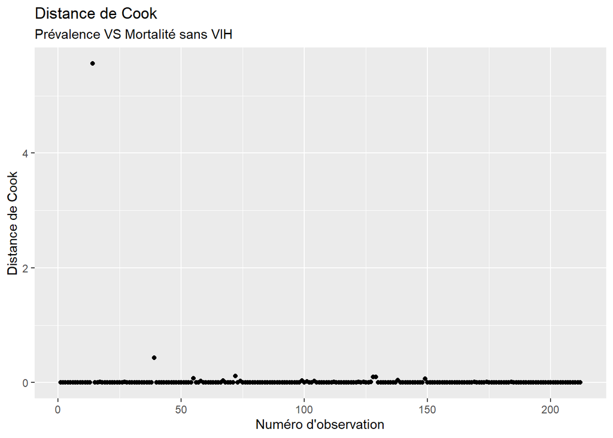

```r
ggplot() +
  aes(x =seq_along(cooks.distance(mortalite_sans_vih_vs_prevalance)), y = cooks.distance(mortalite_sans_vih_vs_prevalance)) +
  geom_point()  +
  xlab("Numéro d'observation") +
  ylab("Distance de Cook") +
  ggtitle("Distance de Cook", subtitle="Prévalence VS Mortalité sans VIH")
```

### Analyse

Interprétation de la Distance de Cook : Ce graphique montre la distance de Cook pour chaque observation dans le modèle de régression, ce qui permet d’identifier les observations qui ont une influence excessive sur les coefficients du modèle.

Description du graphique :

Axe X : Le numéro d’observation, c’est-à-dire l’identifiant de chaque individu dans le jeu de données.

Axe Y : La distance de Cook, qui mesure l’influence de chaque observation sur le modèle. Plus cette distance est grande, plus l’observation a un impact important sur les paramètres du modèle.

Interprétation du graphique :

La majorité des points sont proches de 0 sur l’axe Y, indiquant qu’elles n’ont pas d’influence significative sur le modèle. Cela signifie que ces observations n’affectent pas de manière disproportionnée les coefficients du modèle.

Conclusion :

Le graphique montre qu’une majorité des observations n’ont pas une grande influence, mais quelques points influents peuvent affecter significativement les résultats du modèle.

Ces points pourraient être des outliers ou des observations qui méritent d’être vérifiées plus en détail. Si ces points sont des erreurs de saisie ou des anomalies, leur exclusion ou un traitement approprié pourrait améliorer la robustesse du modèle.

En résumé, il est essentiel de vérifier ces points à haute distance de Cook pour comprendre pourquoi elles exercent une telle influence et décider si elles doivent être exclues ou modifiées.

##residual versus leverage

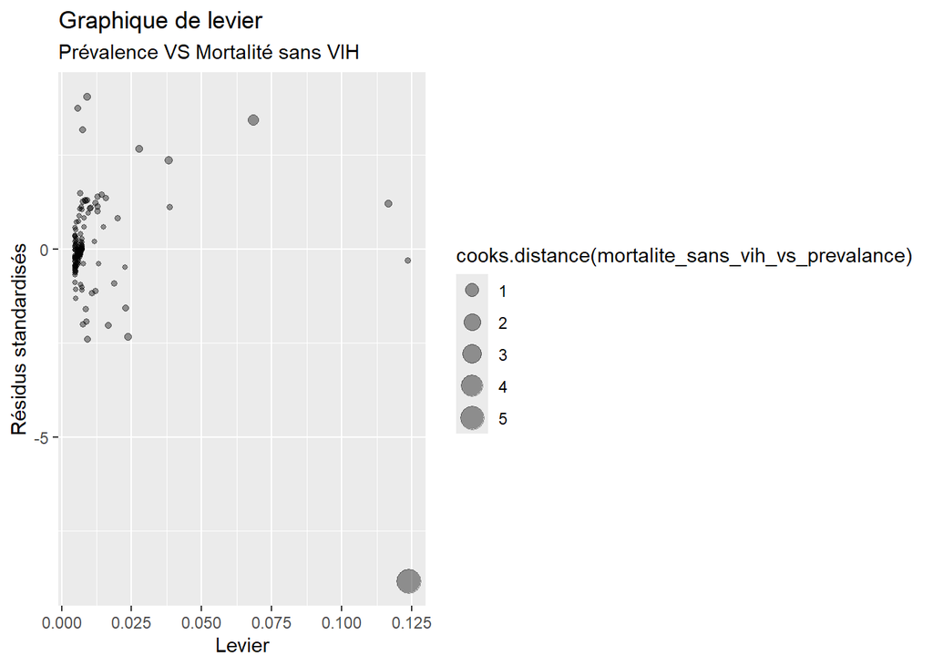

```r
ggplot() +
  aes(x =hatvalues(mortalite_sans_vih_vs_prevalance), y = rstandard(mortalite_sans_vih_vs_prevalance)) +
  geom_point(aes(size=cooks.distance(mortalite_sans_vih_vs_prevalance)),alpha=0.4)  +
  xlab("Levier") +
  ylab("Résidus standardisés") +
  ggtitle("Graphique de levier", subtitle="Prévalence VS Mortalité sans VIH")
```

### Analyse

Ce graphique examine la relation entre les résidus standardisés et le levier des observations dans le modèle de régression, tout en tenant compte de la distance de Cook. Il permet de détecter les points influents, à la fois en termes d’impact sur la régression (résidus) et de leur influence sur le modèle (levier).

Description du graphique :

Axe X (Levier) : Le levier mesure l’influence potentielle d’une observation sur les valeurs ajustées du modèle. Un levier élevé indique qu’une observation est éloignée de la moyenne des autres observations.

Axe Y (Résidus standardisés) : Les résidus standardisés mesurent l’écart entre les valeurs observées et les valeurs ajustées, normalisées pour tenir compte de la variance des erreurs.

Interprétation du graphique : Les points avec un levier élevé sont plus éloignés de la droite de régression, ce qui signifie qu’ils ont une forte capacité à influencer les résultats du modèle.

Les grands cercles (indiquant une distance de Cook élevée) correspondent aux points les plus influents, ceux qui ont à la fois un levier élevé et un résidu important.

En revanche, la majorité des points se trouvent près de l’axe des résidus (proches de zéro), indiquant que la plupart des observations ont une faible influence sur le modèle.

Conclusion : Les points influents (grands cercles) doivent être examinés plus attentivement. Si ces points sont des outliers ou des observations extrêmes, ils pourraient avoir un impact disproportionné sur les résultats du modèle.

Un levier élevé combiné à un résidu important indique qu’une observation a une influence significative sur le modèle, et ces observations doivent être vérifiées pour décider si elles doivent être exclues ou traitées différemment.

En résumé, ce graphique identifie les points influents qui peuvent nécessiter une attention particulière avant d’interpréter pleinement les résultats du modèle.

##II.1.5) incidence & mortalité avec VIH

##nuage de points

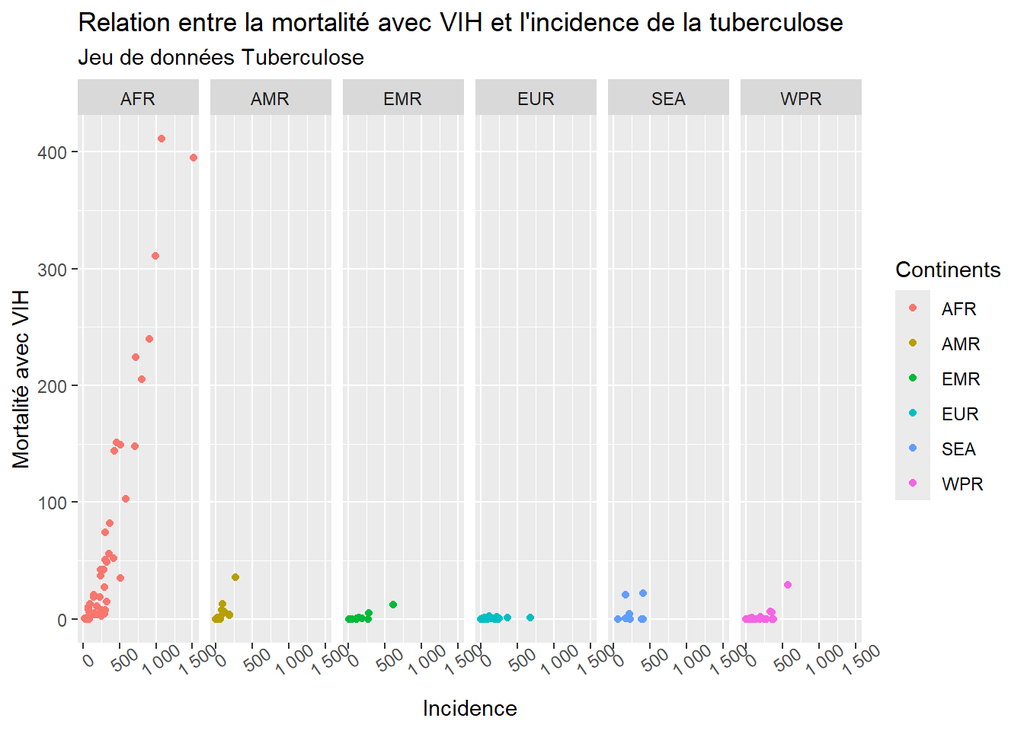

```r
ggplot(TB2_2000)+
  aes(x= `Estimated_incidence_(all_forms)_per_100_000_population`,
      y=`Estimated_mortality_of_TB_cases_who_are_HIV-positive,_per_100_000_population`,
      colour= Region)+
  geom_point()+
  labs(
    x="Incidence",
    y="Mortalité avec VIH",
    colour="Continents"
  )+
  ggtitle("Relation entre la mortalité avec VIH et l'incidence de la tuberculose",
          subtitle = "Jeu de données Tuberculose")+
  scale_x_continuous(labels = scales::label_number(decimal.mark=","))+
  scale_y_continuous(
    labels = scales::label_number(decimal.mark=",")
  )+
  facet_grid(cols=vars(Region))+
  theme(axis.text.x=element_text(angle=35))
```

### Analyse

Description du graphique :

Axe X (Incidence) : Cet axe représente l’incidence de la tuberculose par 100 000 habitants.

Axe Y (Mortalité avec VIH) : Cet axe représente la mortalité liée à la tuberculose chez les personnes vivant avec le VIH par 100 000 habitants.

Couleur des points : Chaque continent est représenté par une couleur différente, permettant ainsi de visualiser les données de chaque région (par exemple, rouge pour l’Afrique, bleu pour l’Europe, etc.).

Interprétation du graphique :

##covariance

```r
TB2_2000 %>% select(`Estimated_incidence_(all_forms)_per_100_000_population`,
`Estimated_mortality_of_TB_cases_who_are_HIV-positive,_per_100_000_population`)%>%cov()
```

```
##                                                                              Estimated_incidence_(all_forms)_per_100_000_population
## Estimated_incidence_(all_forms)_per_100_000_population                                                                    43704.066
## Estimated_mortality_of_TB_cases_who_are_HIV-positive,_per_100_000_population                                               9669.466
##                                                                              Estimated_mortality_of_TB_cases_who_are_HIV-positive,_per_100_000_population
## Estimated_incidence_(all_forms)_per_100_000_population                                                                                           9669.466
## Estimated_mortality_of_TB_cases_who_are_HIV-positive,_per_100_000_population                                                                     3082.145
```

### Analyse

Covariance de l’incidence avec elle-même : 43704.066

La covariance d’une variable avec elle-même est égale à sa variance. Ici, la variance de l’incidence de la tuberculose est de 43704.066, ce qui indique l’étendue de la dispersion des valeurs d’incidence autour de leur moyenne.

Covariance entre l’incidence et la mortalité avec VIH : 9669.466

Cette covariance positive indique qu’il existe une relation linéaire positive entre l’incidence de la tuberculose et la mortalité liée au VIH. Plus précisément, lorsque l’incidence de la tuberculose augmente, la mortalité chez les personnes vivant avec le VIH a tendance à augmenter aussi.

Covariance de la mortalité avec VIH avec elle-même : 3082.145

La covariance de la mortalité avec VIH avec elle-même est la variance de cette variable. Une variance de 3082.145 indique que les valeurs de mortalité sont dispersées autour de leur moyenne.

Conclusion : La covariance entre l’incidence de la tuberculose et la mortalité avec VIH est relativement élevée (9669.466), ce qui confirme l’existence d’une relation positive entre ces deux variables. Cela signifie que dans les régions où l’incidence de la tuberculose est plus élevée, la mortalité liée au VIH tend également à augmenter. Cette information est précieuse pour comprendre comment les deux phénomènes sont liés dans différentes populations.

Toutefois, la covariance seule ne nous permet pas de comparer la force de cette relation entre les variables car elle est influencée par l’unité de mesure de chaque variable. Pour avoir une mesure normalisée de la force de cette relation, il serait préférable de calculer le coefficient de corrélation entre ces deux variables.

##coefficient de corrélation pearson

```r
cor(x=TB2_2000[["Estimated_incidence_(all_forms)_per_100_000_population"]], y=TB2_2000[["Estimated_mortality_of_TB_cases_who_are_HIV-positive,_per_100_000_population"]], method ="pearson")
```

```
## [1] 0.8331344
```

##coefficient de corrélation Spearman

```r
cor(x=TB2_2000[["Estimated_incidence_(all_forms)_per_100_000_population"]], y=TB2_2000[["Estimated_mortality_of_TB_cases_who_are_HIV-positive,_per_100_000_population"]], method ="spearman")
```

```
## [1] 0.6803857
```

### Analyse :

Les coefficients de corrélation mesurent la force et la direction de la relation entre deux variables. Le coefficient de corrélation de Pearson évalue la relation linéaire, tandis que celui de Spearman mesure la relation monotone, qui peut être non linéaire mais toujours dans la même direction.

Résultats des coefficients : Coefficient de corrélation de Pearson : 0.8331344

Ce coefficient élevé et positif indique une relation forte et linéaire entre l’incidence de la tuberculose et la mortalité liée au VIH. Cela suggère qu’une augmentation de l’incidence de la tuberculose est fortement associée à une augmentation de la mortalité chez les personnes vivant avec le VIH. La valeur proche de 1 montre que cette relation linéaire est bien définie.

Coefficient de corrélation de Spearman : 0.6803857

Ce coefficient positif indique une relation monotone modérée à forte entre l’incidence de la tuberculose et la mortalité avec VIH. Une valeur de 0.68 montre que, bien que la relation ne soit pas parfaitement linéaire, les deux variables évoluent dans la même direction. Cela suggère qu’à mesure que l’incidence de la tuberculose augmente, la mortalité liée au VIH augmente également, même si la relation n’est pas strictement linéaire.

Interprétation : Pearson (0.833) : La forte corrélation linéaire entre l’incidence de la tuberculose et la mortalité chez les personnes vivant avec le VIH montre qu’elles varient ensemble de manière très prévisible. À chaque augmentation de l’incidence, la mortalité augmente aussi de manière proportionnelle, ce qui confirme une relation forte et linéaire.

Spearman (0.680) : Bien que la relation ne soit pas parfaitement linéaire, elle reste positive, ce qui signifie que les deux variables suivent un mouvement similaire, même si cette relation est moins précise qu’une relation linéaire. Cela montre que, même dans des cas où les données sont moins bien ajustées à une droite, l’incidence et la mortalité évoluent dans le même sens.

Conclusion : Les deux coefficients de corrélation suggèrent qu’il existe une relation positive entre l’incidence de la tuberculose et la mortalité chez les personnes vivant avec le VIH. Le coefficient de Pearson indique que cette relation est particulièrement forte et linéaire, tandis que celui de Spearman montre qu’elle reste significative, bien que moins précise, en termes monotones. Ces résultats soulignent l’importance de l’incidence de la tuberculose comme facteur prédictif de la mortalité liée au VIH dans la population analysée.

##regression linéaire

```r
mortalite_avec_vih_vs_incidence <-TB2_2000%>% lm(`Estimated_mortality_of_TB_cases_who_are_HIV-positive,_per_100_000_population` ~
                               `Estimated_incidence_(all_forms)_per_100_000_population`,
                             data =.)

# Résumé du modèle
summary(mortalite_avec_vih_vs_incidence)
```

```
##
## Call:
## lm(formula = `Estimated_mortality_of_TB_cases_who_are_HIV-positive,_per_100_000_population` ~
##     `Estimated_incidence_(all_forms)_per_100_000_population`,
##     data = .)
##
## Residuals:
##      Min       1Q   Median       3Q      Max
## -133.183   -9.056    6.541   13.732  189.987
##
## Coefficients:
##                                                           Estimate Std. Error
## (Intercept)                                              -16.38688    2.58580
## `Estimated_incidence_(all_forms)_per_100_000_population`   0.22125    0.01014
##                                                          t value Pr(>|t|)
## (Intercept)                                               -6.337  1.4e-09 ***
## `Estimated_incidence_(all_forms)_per_100_000_population`  21.830  < 2e-16 ***
## ---
## Signif. codes:  0 '***' 0.001 '**' 0.01 '*' 0.05 '.' 0.1 ' ' 1
##
## Residual standard error: 30.78 on 210 degrees of freedom
## Multiple R-squared:  0.6941, Adjusted R-squared:  0.6927
## F-statistic: 476.5 on 1 and 210 DF,  p-value: < 2.2e-16
```

### Analyse

Résidus :

Min = -133.183

1er quartile = -9.056

Médiane = 6.541

3ème quartile = 13.732

Max = 189.987

2. Relation entre les variables :

Intercept (constante) : -16.38688 Cela signifie que lorsque l’incidence de la tuberculose est nulle, la mortalité due à la tuberculose chez les personnes vivant avec le VIH serait de -16.39 décès par 100 000 habitants (valeur théorique, mais non réaliste dans ce cas).

Coefficient de l’incidence de la tuberculose : 0.22125 Pour chaque augmentation de 1 décès par 100 000 habitants dans l’incidence de la tuberculose, la mortalité liée au VIH augmente de 0.22 décès par 100 000 habitants. Cela suggère une relation positive : plus l’incidence de la tuberculose est élevée, plus la mortalité liée au VIH augmente dans cette population.

3. Significativité :

p-value de l’intercept : 1.4e-09 Le p-value extrêmement faible pour l’intercept indique qu’il est hautement significatif.

p-value de la variable indépendante (incidence) : < 2e-16 Le p-value très faible montre que l’incidence est un prédicteur hautement significatif de la mortalité liée au VIH.

4. R-squared (R²) :

R-squared = 0.6941 Le modèle explique environ 69.41% de la variance de la mortalité de la tuberculose chez les personnes vivant avec le VIH. Cela montre que l’incidence est un facteur important pour prédire la mortalité dans ce modèle.

Adjusted R-squared = 0.6927 L’ajustement du modèle reste relativement stable après correction pour le nombre de variables dans le modèle.

5. F-statistic :

F-statistic = 476.5 avec une p-value très faible (< 2.2e-16), ce qui indique que le modèle est globalement significatif et que la relation entre l’incidence de la tuberculose et la mortalité liée au VIH est robuste.

Conclusion : Le modèle montre que l’incidence de la tuberculose est un prédicteur très significatif de la mortalité liée au VIH dans la population générale. Le modèle explique 69.41% de la variance de la mortalité, ce qui en fait un bon ajustement, mais il reste une partie de la variance non expliquée. Le coefficient de l’incidence montre une relation positive entre l’incidence de la tuberculose et la mortalité de la tuberculose chez les personnes vivant avec le VIH. Les p-values faibles et l’F-statistic élevé renforcent l’idée que la relation entre ces deux variables est forte et significative.

##résidus versus valeurs ajustées

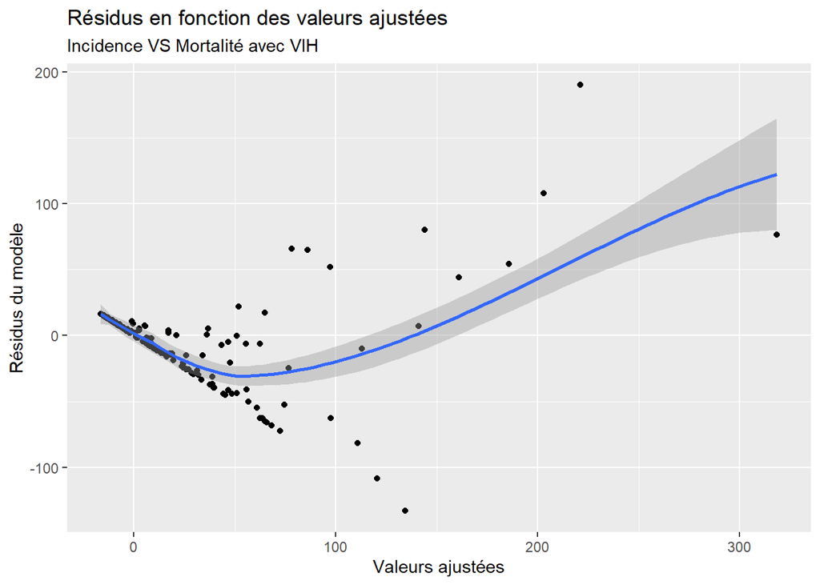

```r
ggplot() +
  aes(x = fitted(mortalite_avec_vih_vs_incidence ), y = residuals(mortalite_avec_vih_vs_incidence  )) +
  geom_point() +  # Nuage de points
  geom_smooth() +
  xlab("Valeurs ajustées") +
  ylab("Résidus du modèle") +
  ggtitle("Résidus en fonction des valeurs ajustées", subtitle = "Incidence VS Mortalité avec VIH")
```

### Analyse

Le graphique montre la relation entre les résidus du modèle de régression (Incidence VS Mortalité avec VIH) et les valeurs ajustées. Ce type de graphique est essentiel pour examiner l’homoscédasticité, c’est-à-dire si les erreurs de prédiction sont distribuées de manière homogène, ou si elles présentent des tendances particulières selon les valeurs ajustées.

1. Description du graphique : Axe X (Valeurs ajustées) : Les valeurs ajustées correspondent aux prédictions du modèle de régression pour chaque observation, calculées en fonction de l’incidence.

Axe Y (Résidus du modèle) : Les résidus représentent la différence entre les valeurs observées et les valeurs prédites par le modèle. Les résidus mesurent l’erreur de prédiction pour chaque observation.

Couleur de la courbe : La courbe lissée (représentée en bleu) montre la tendance générale des résidus en fonction des valeurs ajustées.

2. Interprétation du graphique : Dispersions des résidus :

Courbe lissée (geom_smooth) :

La courbe lissée montre une forme non linéaire, ce qui suggère qu’un modèle linéaire pourrait ne pas s’adapter parfaitement aux données. Cette non-linéarité indique que les résidus ne suivent pas une distribution homogène et que le modèle pourrait ne pas capturer toute la dynamique des données. Les erreurs ne sont pas distribuées de manière aléatoire, ce qui pourrait être le signe d’une relation plus complexe entre l’incidence et la mortalité avec VIH que ce que le modèle linéaire peut expliquer.

Hétéroscédasticité :

La courbe lissée qui présente une forme non linéaire indique également que le modèle linéaire ne s’ajuste pas parfaitement aux données, suggérant qu’une transformation ou l’utilisation d’un autre type de modèle pourrait être nécessaire pour mieux capturer la dynamique entre l’incidence et la mortalité liée au VIH.

En résumé, bien que le modèle offre une certaine précision dans ses prédictions, il ne parvient pas à saisir toute la complexité de la relation entre les variables et présente des problèmes d’homogénéité dans la distribution des erreurs.

##qqplot

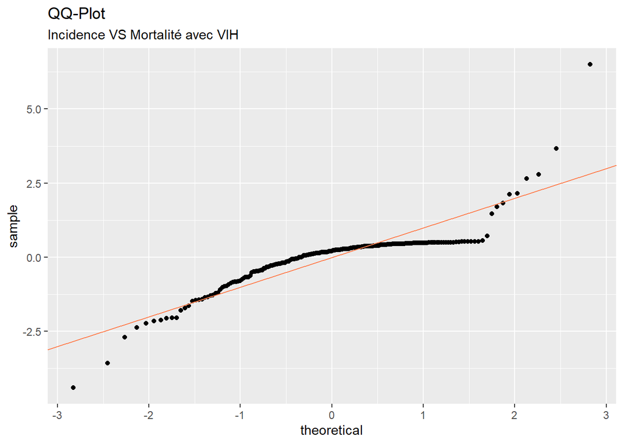

```r
ggplot() +
  geom_qq(aes(sample=rstandard(mortalite_avec_vih_vs_incidence)))+
  geom_abline(color="coral")+
  ggtitle("QQ-Plot", subtitle="Incidence VS Mortalité avec VIH")
```

### Analyse

Le QQ-plot (ou graphique quantile-quantile) montre la distribution des résidus de notre modèle de régression par rapport à une distribution normale théorique. Ce graphique permet de vérifier si les résidus suivent une distribution normale, ce qui est une hypothèse clé dans l’analyse de régression.

1. Description du graphique : Axe X (Theoretical) : L’axe théorique représente les quantiles de la distribution normale théorique (c’est-à-dire les valeurs qu’un ensemble de données parfaitement normal devrait avoir).

Axe Y (Sample) : L’axe des échantillons montre les quantiles des résidus standardisés de votre modèle de régression.

Droite orange : La droite orange représente la régression linéaire théorique si les résidus étaient parfaitement distribués selon une loi normale.

2. Interprétation du graphique : Alignement proche de la droite :

Les points du QQ-plot suivent une ligne droite orange dans la majorité du graphique, ce qui suggère que les résidus suivent assez bien une distribution normale dans cette partie des données. Cela est un bon signe et indique que, globalement, les erreurs de prédiction de votre modèle suivent une distribution normale, ce qui est conforme à une des hypothèses des modèles de régression linéaire.

Écarts aux extrémités :

Cependant, aux extrémités du graphique (aux valeurs négatives et positives élevées), les points commencent à s’éloigner de la droite. Cela indique que les queues de la distribution des résidus sont plus lourdes que celles d’une distribution normale. Cela pourrait suggérer la présence de valeurs extrêmes (outliers) ou une asymétrie dans les données. Les points qui dévient de la droite peuvent être des observations influentes ou des valeurs aberrantes qui méritent une attention particulière.

Queue droite :

La partie droite des points (valeurs positives élevées) montre un écart plus important par rapport à la droite orange, ce qui peut suggérer que le modèle sous-estime la variance des résidus pour les valeurs élevées de l’incidence et de la mortalité avec VIH.

3. Conclusion : Le QQ-plot montre que, dans l’ensemble, les résidus de la régression suivent une distribution normale. Toutefois, l’écart aux extrémités suggère la présence de outliers ou de valeurs influentes. Ces points extrêmes pourraient influer fortement sur les résultats du modèle, ce qui pourrait nuire à la fiabilité de certaines conclusions tirées du modèle.

Il serait utile d’examiner ces points extrêmes plus en détail pour comprendre leur origine. Si ces points sont des erreurs de saisie ou des anomalies, leur exclusion ou traitement pourrait améliorer l’ajustement du modèle et donner des résultats plus fiables.

##scale-location (position-échelle)

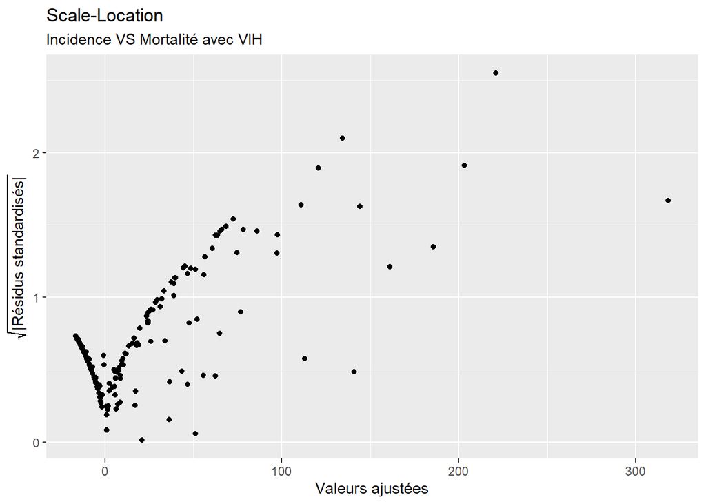

```r
ggplot() +
  aes(x = fitted(mortalite_avec_vih_vs_incidence), y = sqrt(abs(rstandard(mortalite_avec_vih_vs_incidence)))) +
  geom_point()  +
  xlab("Valeurs ajustées") +
  ylab(expression(sqrt("|Résidus standardisés|"))) +
  ggtitle("Scale-Location", subtitle="Incidence VS Mortalité avec VIH")
```

### Analyse :

Le graphique Scale-Location (ou Position-échelle) montre la relation entre les valeurs ajustées (prédictions du modèle) et les résidus standardisés, transformés par la racine carrée des résidus absolus. Ce graphique est utile pour évaluer l’homoscédasticité (variance constante des résidus), une des hypothèses sous-jacentes de la régression linéaire.

1. Description du graphique : Axe X (Valeurs ajustées) : Représente les valeurs ajustées du modèle, c’est-à-dire les prédictions que le modèle fait pour chaque observation.

Axe Y (√|Résidus standardisés|) : L’axe des résidus standardisés, transformés par la racine carrée de la valeur absolue des résidus. Cette transformation permet de mieux visualiser la dispersion des résidus.

2. Interprétation du graphique : Dispersions des résidus :

V Formation :

Hétéroscédasticité :

Ce type de dispersion des résidus est un signe d’hétéroscédasticité, où la variance des erreurs n’est pas constante à travers les différentes valeurs ajustées. Les modèles de régression linéaire, en particulier, supposent que les erreurs doivent avoir une variance constante, donc cette observation suggère qu’un modèle non linéaire pourrait être plus approprié pour ces données.

3. Conclusion : Le graphique Scale-Location suggère qu’il existe un problème d’hétéroscédasticité dans les données, ce qui signifie que la variance des résidus varie selon les valeurs ajustées. Cette violation de l’hypothèse d’homoscédasticité peut affecter l’efficacité et la fiabilité des résultats du modèle de régression linéaire.

Il serait peut-être utile d’explorer des transformations des variables ou d’envisager un modèle non linéaire ou robuste pour mieux ajuster les données et répondre aux problèmes d’hétéroscédasticité.

## distance de cook

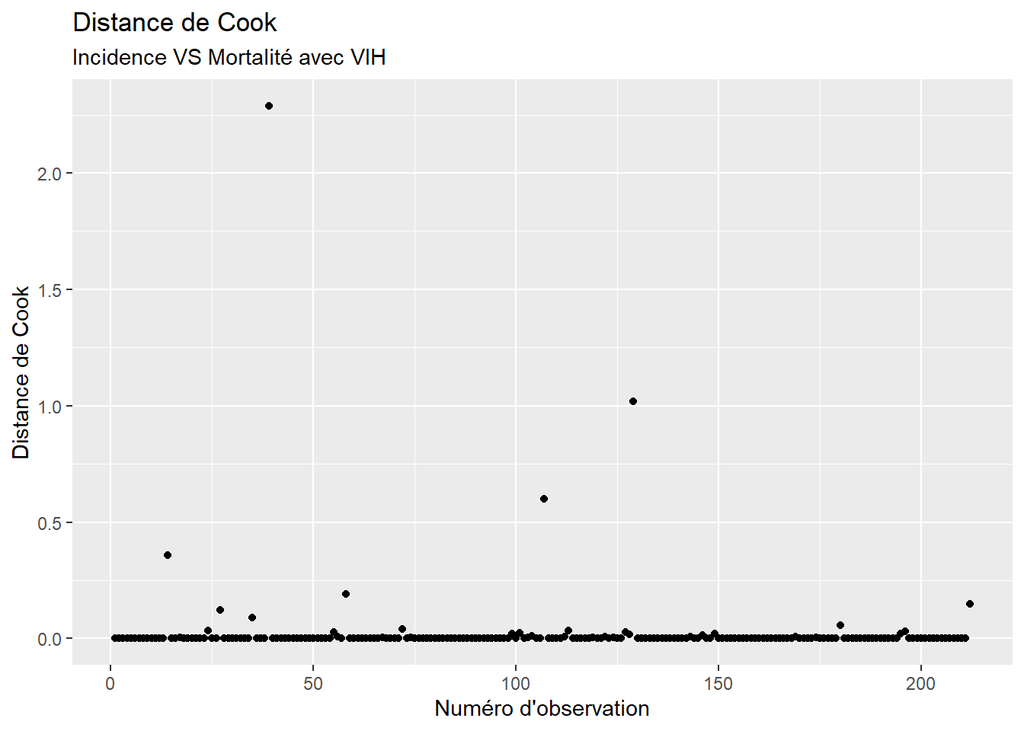

```r
ggplot() +
  aes(x =seq_along(cooks.distance(mortalite_avec_vih_vs_incidence)), y = cooks.distance(mortalite_avec_vih_vs_incidence)) +
  geom_point()  +
  xlab("Numéro d'observation") +
  ylab("Distance de Cook") +
  ggtitle("Distance de Cook", subtitle="Incidence VS Mortalité avec VIH")
```

### Analyse

Ce graphique montre la distance de Cook pour chaque observation dans le modèle de régression. La distance de Cook mesure l’impact de chaque observation sur les paramètres du modèle. Une grande distance de Cook indique que l’observation a une forte influence sur le modèle et ses résultats.

1. Description du graphique : Axe X (Numéro d’observation) : Représente l’identifiant unique de chaque observation dans l’ensemble de données.

Axe Y (Distance de Cook) : Représente la distance de Cook, une mesure qui évalue l’impact de chaque observation sur les coefficients du modèle. Plus cette distance est élevée, plus l’observation a un impact significatif sur le modèle.

2. Interprétation du graphique : Observation générale :

La majorité des points ont une distance de Cook très faible, ce qui indique qu’ils n’ont pas une influence excessive sur les coefficients du modèle.

Points influents :

Quelques observations, notamment celles situées entre 30 et 50, montrent une distance de Cook relativement élevée. Cela suggère que ces points ont un impact important sur le modèle, soit en raison de valeurs extrêmes (outliers) soit en raison de leur position influente dans l’ensemble des données.

Outliers potentiels :

Les observations ayant des distances de Cook élevées pourraient être des outliers qui affectent de manière disproportionnée le modèle. Il est important de vérifier si ces points sont des erreurs de saisie, des anomalies, ou s’ils ont une raison justifiable d’exister dans le jeu de données.

3. Conclusion : Ce graphique suggère qu’une petite fraction des observations a une influence significative sur le modèle. Les points avec des distances de Cook élevées méritent une vérification plus approfondie pour déterminer si elles sont des erreurs de saisie, des valeurs aberrantes, ou si elles doivent être prises en compte différemment dans l’analyse.

Si ces points influents sont des erreurs ou des anomalies, leur exclusion ou leur traitement pourrait améliorer l’ajustement du modèle et rendre les résultats plus robustes.

Résumé : Bien que la majorité des observations n’aient pas une influence majeure sur le modèle, il est conseillé de prêter attention aux points avec des distances de Cook élevées. Ceux-ci pourraient affecter de manière disproportionnée les résultats du modèle et méritent d’être examinés plus en détail avant d’interpréter les conclusions.

##residual versus leverage

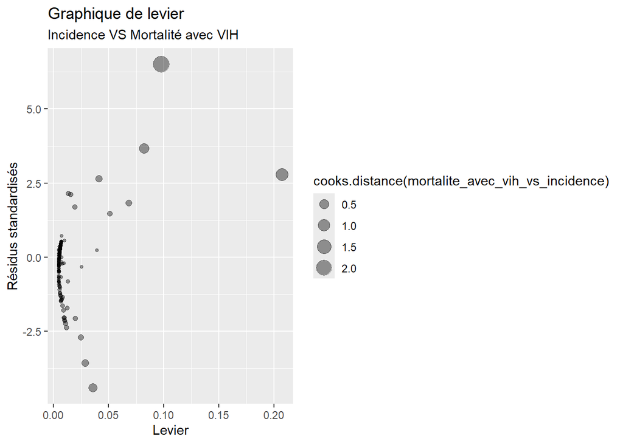

```r
ggplot() +
  aes(x =hatvalues(mortalite_avec_vih_vs_incidence), y = rstandard(mortalite_avec_vih_vs_incidence)) +
  geom_point(aes(size=cooks.distance(mortalite_avec_vih_vs_incidence)),alpha=0.4)  +
  xlab("Levier") +
  ylab("Résidus standardisés") +
  ggtitle("Graphique de levier",subtitle="Incidence VS Mortalité avec VIH")
```

### Analyse

Graphique de Levier Ce graphique examine la relation entre les résidus standardisés et le levier des observations dans le modèle de régression, tout en tenant compte de la distance de Cook. Il permet de détecter les points influents, à la fois en termes d’impact sur la régression (résidus) et de leur influence sur le modèle (levier).

1. Description du graphique : Axe X (Levier) : Le levier mesure l’influence potentielle d’une observation sur les valeurs ajustées du modèle. Un levier élevé indique qu’une observation est éloignée de la moyenne des autres observations.

Axe Y (Résidus standardisés) : Les résidus standardisés mesurent l’écart entre les valeurs observées et les valeurs ajustées, normalisées pour tenir compte de la variance des erreurs.

Taille des points : La taille des points dans le graphique correspond à la distance de Cook, qui montre l’influence globale d’une observation sur les paramètres du modèle. Plus la taille est grande, plus l’observation a un effet important sur le modèle.

2. Interprétation du graphique : Observations avec levier élevé : Les points avec un levier élevé sont situés plus loin de l’axe X, ce qui signifie qu’ils ont une plus grande capacité à influencer les résultats du modèle. Ces points doivent être surveillés, car ils peuvent fausser les résultats de régression.

Observations influentes : Les points de grande taille (indiquant une distance de Cook élevée) sont les plus influents. Ceux-ci sont situés à la fois à une position de levier élevé et possèdent un résidu important, ce qui signifie qu’ils affectent à la fois l’ajustement du modèle et la variabilité des erreurs.

Observations non influentes : La majorité des points sont situés près de l’axe des résidus, ce qui indique que la plupart des observations ont une faible influence sur le modèle.

3. Conclusion : Les points influents (représentés par les grands cercles) doivent être examinés plus attentivement. Si ces points sont des outliers ou des observations extrêmes, elles peuvent avoir un impact disproportionné sur les résultats du modèle.

Observation clé : Un levier élevé combiné à un résidu important indique qu’une observation a une influence significative sur le modèle. Ces observations méritent d’être vérifiées pour comprendre pourquoi elles exercent une telle influence sur les résultats et décider si elles doivent être exclues ou traitées différemment.

Résumé : Ce graphique identifie les points influents dans le modèle. Il est crucial de vérifier ces points, car leurs effets peuvent fausser les conclusions du modèle de régression. En résumé, ces points nécessitent une attention particulière avant de tirer des conclusions définitives.

##II.1.6) incidence & mortalité sans vih

##nuage de points

[figure not shown]

```r
ggplot(TB2_2000)+
  aes(x= `Estimated_incidence_(all_forms)_per_100_000_population`,
      y=`Estimated_mortality_of_TB_cases_(all_forms,_excluding_HIV)_per_100_000_population`,
      colour= Region)+
  geom_point()+
  labs(
    x="Incidence",
    y="Mortalité avec VIH",
    colour="Continents"
  )+
  ggtitle("Relation entre la mortalité sans VIH et l'incidence de la tuberculose",
          subtitle = "Jeu de données Tuberculose")+
  scale_x_continuous(labels = scales::label_number(decimal.mark=","))+
  scale_y_continuous(
    labels = scales::label_number(decimal.mark=",")
  )+
  facet_grid(cols=vars(Region))+
  theme(axis.text.x=element_text(angle=35))
```

### Analyse

Ce graphique montre la relation entre l’incidence et la mortalité de la tuberculose pour différents continents, et ce, à partir des données disponibles pour chaque région.

1. Description du graphique : Axe X (Incidence) : Il représente le nombre de nouveaux cas de tuberculose (incidence) par 100 000 habitants.

Couleur des points : Chaque continent est représenté par une couleur différente (par exemple, rouge pour l’Afrique, bleu pour l’Europe, etc.), ce qui permet de différencier les observations selon les régions géographiques.

Facettes : Le graphique est divisé en plusieurs facettes, chacune représentant un continent. Cette organisation permet de comparer la relation entre incidence et mortalité pour chaque région du monde.

2. Interprétation du graphique : Relation positive générale : Pour de nombreux continents, on peut observer une relation positive entre l’incidence et la mortalité. Cela signifie qu’à mesure que l’incidence de la tuberculose augmente dans une région, la mortalité liée à la tuberculose tend également à augmenter. Cela reflète probablement une propagation plus large de la maladie et un taux de mortalité plus élevé, surtout en présence de VIH.

Afrique (AFR - rouge) : Dans cette région, on observe une forte concentration de points en bas à gauche du graphique, avec une incidence faible et une mortalité modérée à faible. Cependant, il y a également quelques valeurs extrêmes (points dispersés), ce qui peut suggérer une hétérogénéité dans la relation entre incidence et mortalité. Certains pays en Afrique ont des systèmes de santé moins développés, ce qui pourrait expliquer ces différences.

Amériques (AMR - orange) : Les points sont plus concentrés, mais certains pays montrent une tendance plus faible à la fois en incidence et en mortalité. Cela peut refléter des politiques de santé publique plus efficaces ou une meilleure gestion des cas.

Europe (EUR - bleu) : Ici, on observe une relation plus linéaire, avec une meilleure corrélation entre les deux variables, ce qui pourrait indiquer une surveillance plus stricte et un accès amélioré aux soins.

3. Conclusion : Le graphique met en lumière que l’incidence et la mortalité de la tuberculose sont généralement liées, mais que cette relation varie considérablement d’un continent à l’autre. Les facteurs socio-économiques, les systèmes de santé, ainsi que les programmes de lutte contre le VIH peuvent expliquer ces différences. En particulier, les régions avec des ressources de santé limitées peuvent montrer une variabilité importante dans la gestion de la tuberculose et ses conséquences.

Il serait pertinent de poursuivre cette analyse en examinant les facteurs sous-jacents dans chaque région pour comprendre pourquoi certaines régions présentent une relation plus forte entre l’incidence et la mortalité, tandis que d’autres montrent une relation moins marquée.

Résumé : L’incidence et la mortalité de la tuberculose sont généralement corrélées, mais la force de cette relation varie en fonction des continents. Les facteurs locaux, notamment les systèmes de santé, jouent un rôle clé dans la gestion de la maladie et de ses impacts.

## covariance

```r
TB2_2000 %>% select(`Estimated_incidence_(all_forms)_per_100_000_population`,
`Estimated_mortality_of_TB_cases_(all_forms,_excluding_HIV)_per_100_000_population`)%>%cov()
```

```
##                                                                                   Estimated_incidence_(all_forms)_per_100_000_population
## Estimated_incidence_(all_forms)_per_100_000_population                                                                         43704.066
## Estimated_mortality_of_TB_cases_(all_forms,_excluding_HIV)_per_100_000_population                                               5630.678
##                                                                                   Estimated_mortality_of_TB_cases_(all_forms,_excluding_HIV)_per_100_000_population
## Estimated_incidence_(all_forms)_per_100_000_population                                                                                                     5630.678
## Estimated_mortality_of_TB_cases_(all_forms,_excluding_HIV)_per_100_000_population                                                                          1208.579
```

### Analyse :

La covariance entre l’incidence de la tuberculose et la mortalité de la tuberculose est positivement élevée (valeur de 5630.678). Cela indique qu’il existe une forte relation positive entre l’incidence et la mortalité : lorsque l’incidence augmente, la mortalité a tendance à augmenter également. Cela est logique car plus de personnes sont affectées par la tuberculose, plus il est probable que le nombre de décès augmente, en particulier dans les zones où les soins de santé sont limités.

La variance pour chaque variable est indiquée sur la diagonale de la matrice :

La variance de l’incidence est 43704.066, ce qui signifie qu’il existe une certaine dispersion des valeurs d’incidence autour de la moyenne.

La variance de la mortalité est 1208.579, ce qui suggère une variabilité plus faible de la mortalité par rapport à l’incidence. Cela peut indiquer que la mortalité suit une tendance plus homogène, même si la distribution des cas d’incidence est plus dispersée.

2. Conclusion : La covariance positive et élevée entre l’incidence et la mortalité indique une relation forte entre ces deux variables. Cela suggère que dans les pays ou régions où l’incidence de la tuberculose est élevée, la mortalité a également tendance à être élevée, bien que le degré exact de cette relation puisse varier en fonction des facteurs de santé publique et des ressources disponibles dans chaque région.

En résumé, la covariance entre l’incidence et la mortalité de la tuberculose est assez forte et positive, indiquant que ces deux variables évoluent ensemble de manière similaire. Pour mieux comprendre cette relation, il pourrait être utile de compléter cette analyse avec des outils comme la corrélation ou une régression linéaire, afin de quantifier plus précisément la force de la relation et d’éventuellement contrôler d’autres facteurs influents.

##coefficient de corrélation pearson

```r
cor(x=TB2_2000[["Estimated_incidence_(all_forms)_per_100_000_population"]], y=TB2_2000[["Estimated_mortality_of_TB_cases_(all_forms,_excluding_HIV)_per_100_000_population"]], method ="pearson")
```

```
## [1] 0.7747513
```

##coefficient de corrélation Spearman

```r
cor(x=TB2_2000[["Estimated_incidence_(all_forms)_per_100_000_population"]], y=TB2_2000[["Estimated_mortality_of_TB_cases_(all_forms,_excluding_HIV)_per_100_000_population"]], method ="spearman")
```

```
## [1] 0.9196434
```

### Analyse

1. Coefficient de corrélation de Pearson : 0.7748 Le coefficient de corrélation de Pearson mesure la force et la direction de la relation linéaire entre deux variables quantitatives. Il varie entre -1 et 1, où :

1 indique une relation linéaire parfaite et positive,

-1 indique une relation linéaire parfaite et négative,

0 indique qu’il n’y a pas de relation linéaire.

Dans notre cas, un coefficient de 0.7748 indique une forte relation positive entre l’incidence de la tuberculose et la mortalité des cas de tuberculose (hors VIH). En d’autres termes, à mesure que l’incidence de la tuberculose augmente, la mortalité semble également augmenter, et cette relation est relativement bien définie sur un modèle linéaire.

Cette valeur suggère que, bien que la relation entre l’incidence et la mortalité soit forte et positive, elle n’est pas parfaitement linéaire (un coefficient de 1.0 signifierait une relation linéaire parfaite). Cependant, une corrélation de 0.77 est tout de même significative et indique une relation robuste entre ces deux variables.

2. Coefficient de corrélation de Spearman : 0.9196 Le coefficient de corrélation de Spearman mesure la force et la direction de la relation monotone (mais pas nécessairement linéaire) entre deux variables. Il varie également entre -1 et 1, avec :

1 indiquant une relation monotone parfaite et positive,

-1 indiquant une relation monotone parfaite et négative,

0 indiquant qu’il n’y a pas de relation monotone.

Le coefficient de 0.9196 pour Spearman indique une relation monotone très forte entre l’incidence de la tuberculose et la mortalité des cas de tuberculose (hors VIH). Cela signifie que même si la relation entre les deux variables n’est pas parfaitement linéaire, elle reste très forte et les deux variables tendent à évoluer dans la même direction (qu’elles augmentent ou diminuent ensemble de manière systématique).

Le fait que le coefficient de Spearman soit plus élevé que celui de Pearson (0.9196 contre 0.7748) suggère que bien que la relation soit forte et positive, elle peut ne pas être parfaitement linéaire. Spearman capture donc une tendance générale entre les deux variables, même si cette relation est plus complexe et peut comporter des variations non linéaires.

Le coefficient de Pearson (0.7748) montre qu’il existe une forte relation linéaire positive entre l’incidence et la mortalité de la tuberculose, ce qui indique que, globalement, plus l’incidence augmente, plus la mortalité tend à augmenter de manière linéaire.

Le coefficient de Spearman (0.9196) est encore plus élevé, ce qui suggère qu’une relation monotone très forte existe entre ces deux variables, même si elle n’est pas strictement linéaire.

En résumé, les deux coefficients indiquent qu’il existe une forte relation entre l’incidence et la mortalité de la tuberculose. Cependant, la relation est probablement plus complexe que ce que le modèle linéaire de Pearson pourrait suggérer, et une relation monotone bien définie est mieux capturée par Spearman.

##regression linéaire

```r
mortalite_sans_vih_vs_incidence <-TB2_2000%>% lm(`Estimated_mortality_of_TB_cases_(all_forms,_excluding_HIV)_per_100_000_population` ~
                               `Estimated_incidence_(all_forms)_per_100_000_population`,
                             data =.)

# Résumé du modèle
summary(mortalite_sans_vih_vs_incidence)
```

```
##
## Call:
## lm(formula = `Estimated_mortality_of_TB_cases_(all_forms,_excluding_HIV)_per_100_000_population` ~
##     `Estimated_incidence_(all_forms)_per_100_000_population`,
##     data = .)
##
## Residuals:
##     Min      1Q  Median      3Q     Max
## -72.493  -5.837  -3.792  -0.757  88.832
##
## Coefficients:
##                                                          Estimate Std. Error
## (Intercept)                                              3.086585   1.851079
## `Estimated_incidence_(all_forms)_per_100_000_population` 0.128836   0.007255
##                                                          t value Pr(>|t|)
## (Intercept)                                                1.667   0.0969 .
## `Estimated_incidence_(all_forms)_per_100_000_population`  17.757   <2e-16 ***
## ---
## Signif. codes:  0 '***' 0.001 '**' 0.01 '*' 0.05 '.' 0.1 ' ' 1
##
## Residual standard error: 22.03 on 210 degrees of freedom
## Multiple R-squared:  0.6002, Adjusted R-squared:  0.5983
## F-statistic: 315.3 on 1 and 210 DF,  p-value: < 2.2e-16
```

### Analyse :

Tout d’abord, les résidus représentent la différence entre les valeurs observées et les valeurs prédites par le modèle. Voici les résultats des résidus :

Min : -72.493

1er quartile (Q1) : -5.837

Médiane : -3.792

3ème quartile (Q3) : -0.757

Max : 88.832

Les résidus sont assez dispersés, avec des valeurs allant de -72.493 à 88.832. Bien qu’il y ait une certaine variabilité dans les erreurs de prédiction, cela ne semble pas biaisé de manière significative, car la médiane des résidus est proche de zéro. Cependant, la grande plage des résidus suggère qu’il existe quelques observations où le modèle ne prédit pas bien la mortalité.

Relation entre les variables : Le modèle montre que l’incidence de la tuberculose est positivement liée à la mortalité de la tuberculose (sans VIH).

Le coefficient de l’incidence est de 0.1288, ce qui signifie que pour chaque augmentation de 1 cas par 100 000 habitants dans l’incidence de la tuberculose, la mortalité de la tuberculose (sans VIH) augmente de 0.1288 par 100 000 habitants.

Significativité : Le p-value pour l’incidence est très faible (< 2e-16), ce qui signifie que la relation entre l’incidence et la mortalité est hautement significative. L’incidence est donc un facteur significatif pour prédire la mortalité de la tuberculose.

Le p-value pour l’intercept est de 0.0969, ce qui est supérieur à 0.05, ce qui signifie que l’intercept n’est pas significatif à un niveau de confiance de 95%. Cela suggère que l’inclusion de l’intercept peut ne pas être nécessaire, bien qu’il ne soit pas improbable dans ce cas.

R-squared : Le R-squared est de 0.6002, ce qui signifie que 60.02% de la variance de la mortalité (sans VIH) est expliquée par l’incidence de la tuberculose. Cela montre que l’incidence est un facteur important pour prédire la mortalité, mais qu’il existe d’autres facteurs non pris en compte dans ce modèle, car environ 40% de la variance reste inexpliquée.

Le R-squared ajusté est de 0.5983, ce qui montre que le modèle s’ajuste bien aux données et prend en compte le nombre de variables.

F-statistic : Le F-statistic de 315.3 avec une p-value très faible (< 2.2e-16) indique que le modèle est globalement significatif. Cela montre que la relation entre l’incidence et la mortalité est robuste, et le modèle dans son ensemble est fiable.

Conclusion : Le modèle de régression montre que l’incidence de la tuberculose est un prédicteur très significatif de la mortalité de la tuberculose (sans VIH) dans la population, expliquant environ 60% de la variance dans la mortalité. L’incidence est donc un facteur clé pour comprendre et prédire les tendances de mortalité liées à la tuberculose. Bien que le modèle montre une relation significative et robuste, il reste de la variance inexpliquée, suggérant qu’il existe d’autres facteurs non inclus dans le modèle qui influencent la mortalité.

##résidus versus valeurs ajustées

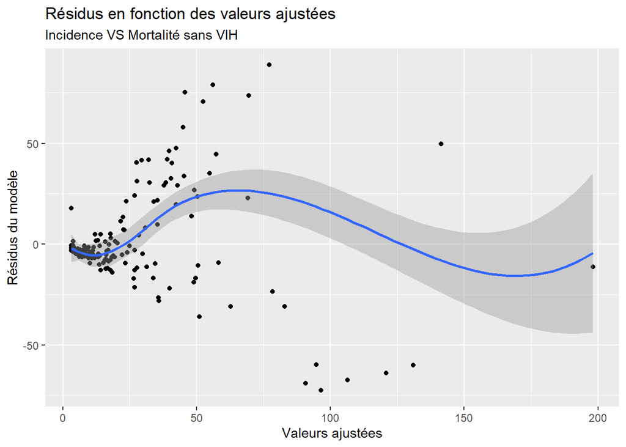

```r
ggplot() +
  aes(x = fitted(mortalite_sans_vih_vs_incidence), y = residuals(mortalite_sans_vih_vs_incidence )) +
  geom_point() +  # Nuage de points
  geom_smooth() +
  xlab("Valeurs ajustées") +
  ylab("Résidus du modèle") +
  ggtitle("Résidus en fonction des valeurs ajustées", subtitle = "Incidence VS Mortalité sans VIH")
```

### Analyse

Axe Y (Résidus du modèle) : Il représente les différences entre les valeurs observées (réelles) et les valeurs ajustées (prédites) pour chaque observation.

La courbe bleue montre la tendance générale des résidus en fonction des valeurs ajustées.

2. Interprétation du graphique : Comportement des résidus :

Variabilité des erreurs :

Relation non linéaire :

La courbe lissée (geom_smooth) montre une forme non linéaire des résidus par rapport aux valeurs ajustées. Cela suggère que le modèle linéaire ne s’ajuste pas parfaitement aux données, car les erreurs de prédiction ne sont pas distribuées de manière homogène à travers les différentes valeurs ajustées.

Ce comportement non linéaire des résidus pourrait signifier qu’une relation plus complexe que la simple linéarité existe entre les variables.

Problème de linéarité : La courbe lissée montre que la relation entre les variables semble plus complexe qu’une simple relation linéaire. Cela suggère que l’ajustement du modèle pourrait être amélioré, potentiellement par l’utilisation d’un modèle non linéaire.

En résumé, bien que le modèle linéaire ait une certaine validité, l’analyse des résidus indique qu’il ne capture pas totalement la complexité de la relation entre l’incidence et la mortalité de la tuberculose. Des ajustements au modèle, ou l’exploration d’un modèle non linéaire, pourraient améliorer la précision des prédictions.

##qqplot

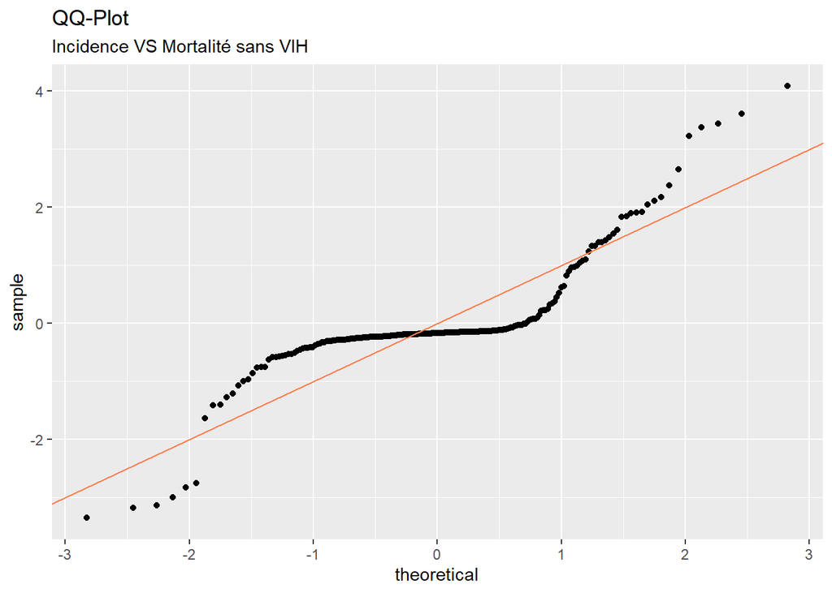

```r
ggplot() +
  geom_qq(aes(sample=rstandard(mortalite_sans_vih_vs_incidence)))+
  geom_abline(color="coral")+
  ggtitle("QQ-Plot", subtitle="Incidence VS Mortalité sans VIH")
```

### analyse :

1. Description du graphique : Axe X (Théorique) : Il représente les quantiles de la distribution normale théorique.

Axe Y (Échantillon) : Il représente les quantiles des résidus standardisés de notre modèle.

Les points du graphique indiquent la position des résidus par rapport à la distribution normale théorique. La droite orange représente la ligne théorique que les points devraient suivre si les résidus suivaient parfaitement une distribution normale.

Écarts aux extrémités :

Aux extrémités du graphique, les points s’éloignent de la droite, tant dans les valeurs négatives que positives élevées. Ce phénomène indique que les résidus présentent des queues plus lourdes que ce qui serait attendu d’une distribution normale.

Les points qui dévient dans les queues de la distribution pourraient être des outliers ou des valeurs extrêmes. Cela suggère qu’il y a une asymétrie dans les résidus, ou que des anomalies (valeurs aberrantes) sont présentes dans les données.

Recommandation : Il serait prudent d’examiner ces points extrêmes (les outliers) plus en détail pour vérifier si elles sont des erreurs de saisie ou des observations rares mais valides. Si ces points ont un impact disproportionné sur les résultats du modèle, des techniques robustes ou des transformations des données pourraient être envisagées pour améliorer l’ajustement du modèle et les résultats des tests statistiques.

##scale-location (position-échelle)

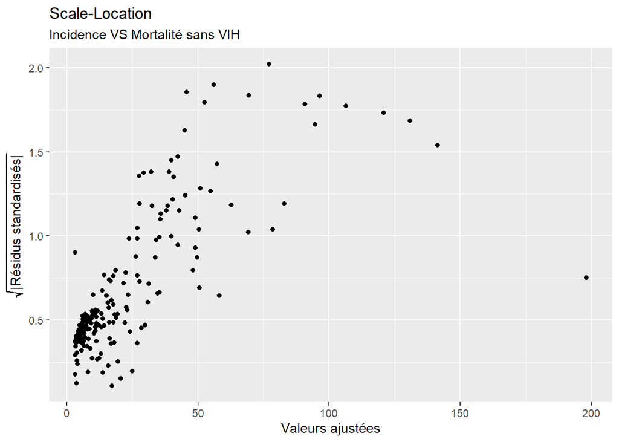

```r
ggplot() +
  aes(x = fitted(mortalite_sans_vih_vs_incidence), y = sqrt(abs(rstandard(mortalite_sans_vih_vs_incidence)))) +
  geom_point()  +
  xlab("Valeurs ajustées") +
  ylab(expression(sqrt("|Résidus standardisés|"))) +
  ggtitle("Scale-Location", subtitle="Incidence VS Mortalité sans VIH")
```

### Analyse :

1. Description du graphique : Axe X (Valeurs ajustées) : Les valeurs ajustées (ou prédictions du modèle) pour chaque observation. Cela représente les valeurs prédites par le modèle de régression en fonction des variables indépendantes.

Axe Y (Résidus standardisés) : Les résidus standardisés, transformés par la racine carrée de la valeur absolue des résidus. Cette transformation permet de mieux visualiser la dispersion des résidus tout en réduisant l’impact des valeurs extrêmes.

## distance de cook

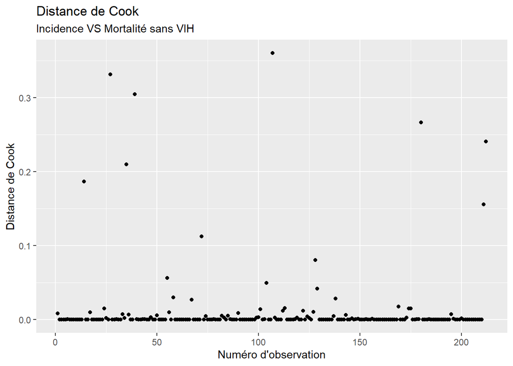

```r
ggplot() +
  aes(x =seq_along(cooks.distance(mortalite_sans_vih_vs_incidence)), y = cooks.distance(mortalite_sans_vih_vs_incidence)) +
  geom_point()  +
  xlab("Numéro d'observation") +
  ylab("Distance de Cook") +
  ggtitle("Distance de Cook", subtitle="Incidence VS Mortalité sans VIH")
```

### Analyse :

1. Description du graphique : Axe X (Numéro d’observation) : L’axe des abscisses représente le numéro d’observation, soit l’identifiant unique de chaque observation dans le jeu de données. Chaque point correspond donc à une observation spécifique dans le modèle.

Axe Y (Distance de Cook) : L’axe des ordonnées représente la distance de Cook, qui mesure l’influence de chaque observation sur les coefficients du modèle de régression. Plus la distance de Cook est grande, plus une observation a un impact important sur les paramètres du modèle.

2. Interprétation du graphique : Observations avec faible distance de Cook : La majorité des points sont concentrés près de zéro sur l’axe des ordonnées, ce qui suggère que la plupart des observations ont une influence négligeable sur les résultats du modèle. Ces points ne sont pas considérés comme des points influents.

Points avec grande distance de Cook : Quelques points situés au-dessus de 0.2 ont une distance de Cook relativement élevée, ce qui suggère qu’elles ont un impact significatif sur le modèle. Ces points sont probablement des outliers ou des observations influentes, qui nécessitent une attention particulière pour évaluer leur validité ou leur caractère exceptionnel.

3. Conclusion : Observations influentes : La présence de quelques points avec des distances de Cook élevées indique qu’une petite fraction des observations a un impact important sur le modèle. Ces points pourraient perturber l’ajustement du modèle et influencer les résultats de manière disproportionnée.

Vérification des points influents : Il est important d’examiner ces points de plus près. Si ces points sont des erreurs de saisie, des anomalies, ou simplement des outliers, il serait judicieux de les exclure du modèle ou de les traiter d’une manière appropriée pour améliorer la précision du modèle.

En résumé, bien que la plupart des observations n’aient pas une influence majeure, les points présentant des distances de Cook élevées doivent être examinés attentivement pour comprendre leur impact sur le modèle et décider de leur traitement approprié.

##residual versus leverage

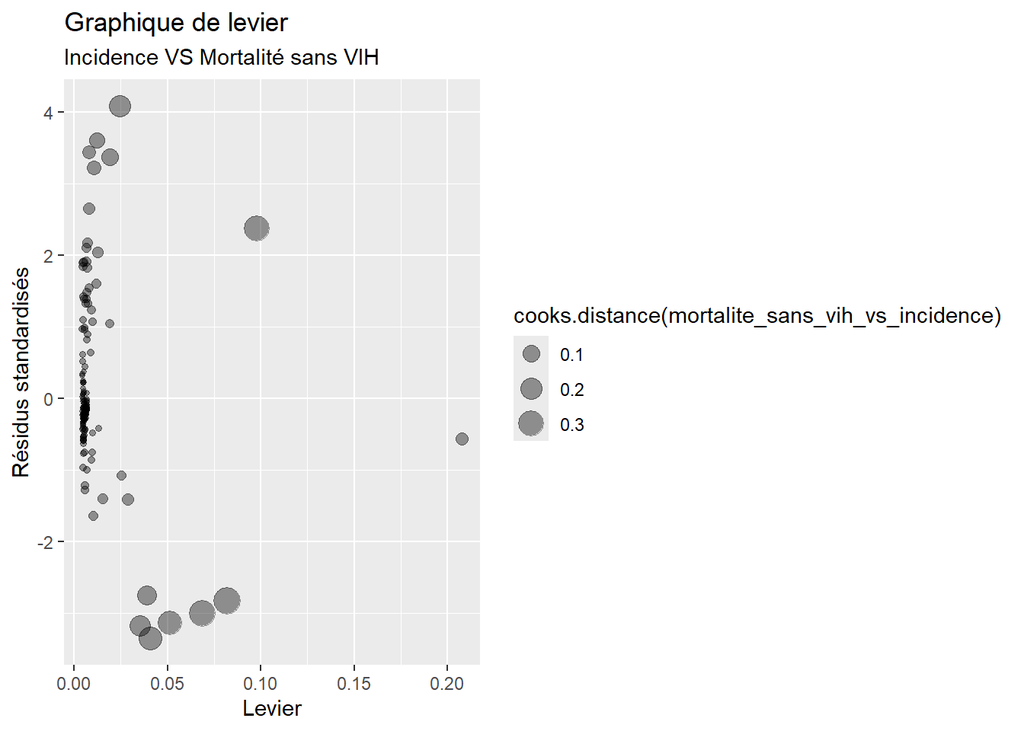

```r
ggplot() +
  aes(x =hatvalues(mortalite_sans_vih_vs_incidence), y = rstandard(mortalite_sans_vih_vs_incidence)) +
  geom_point(aes(size=cooks.distance(mortalite_sans_vih_vs_incidence)),alpha=0.4)  +
  xlab("Levier") +
  ylab("Résidus standardisés") +
  ggtitle("Graphique de levier", subtitle="Incidence VS Mortalité sans VIH")
```

### Analyse :

1. Description du graphique : Axe X (Levier) : Cet axe représente l’influence potentielle de chaque observation sur les valeurs ajustées du modèle. Un levier élevé indique qu’une observation est éloignée de la moyenne des autres observations, ce qui lui permet d’influencer considérablement les résultats du modèle.

Axe Y (Résidus standardisés) : Les résidus standardisés représentent la différence entre les valeurs observées et les valeurs ajustées du modèle, normalisées pour tenir compte de la variance des erreurs.

2. Interprétation du graphique : Les points ayant un levier élevé sont éloignés de la droite de régression, ce qui signifie qu’ils ont une capacité significative à influencer les résultats du modèle. Ces points sont souvent des observations extrêmes ou des valeurs aberrantes qui peuvent influencer les résultats du modèle de manière disproportionnée.

Les grands cercles (indiquant une distance de Cook élevée) correspondent aux points les plus influents, ceux qui ont à la fois un levier élevé et un résidu important. Ces points sont des observations qui exercent une grande influence sur l’ajustement du modèle.

La majorité des points sont proches de l’axe des résidus (c’est-à-dire autour de zéro), ce qui suggère que ces observations ont une faible influence sur le modèle. Ces points sont plus représentatifs de la tendance générale du modèle.

3. Conclusion : Le graphique identifie quelques points influents (grands cercles) qui doivent être examinés de plus près. Ces points peuvent être des outliers ou des observations extrêmes qui ont un impact disproportionné sur le modèle.

Les observations avec un levier élevé et un résidu important doivent être vérifiées attentivement pour comprendre pourquoi elles exercent une influence aussi forte sur le modèle. Si ces points sont des erreurs de saisie ou des anomalies, leur exclusion ou leur traitement pourrait améliorer l’ajustement du modèle.

En résumé, ce graphique identifie les points influents, qui doivent être pris en compte avant de tirer des conclusions définitives sur le modèle de régression.

Cela montre qu’une petite fraction des observations a un impact significatif sur les résultats du modèle, et il est crucial de les examiner pour s’assurer qu’elles ne faussent pas l’analyse.

#II.B) Analyse qualitative bivariée #II.2.1)variable det_case & region_facteur

## tableau de contingence (ligne 486 posit cloud aissa)

```r
# Créer le tableau de contingence pour det_case et region_facteur
contingence_det_region <- TB2_2000 %>%
  select(det_case, region_facteur) %>%
  table()

# Calculer les fréquences conditionnelles pour la variable det_case par region_facteur
conditional_det_region1 <- contingence_det_region
conditional_det_region2 <- contingence_det_region

# Normalisation pour les colonnes (par région)
for(j in 1:ncol(conditional_det_region1)) {  # Normalisation sur chaque colonne (par région)
  conditional_det_region1[,j] <- round(conditional_det_region1[,j] / sum(conditional_det_region1[,j]), digits = 2)
}

# Normalisation pour les lignes (par det_case)
for(i in 1:nrow(conditional_det_region2)) {  # Normalisation sur chaque ligne (par niveau de détection)
  conditional_det_region2[i,] <- round(conditional_det_region2[i,] / sum(conditional_det_region2[i,]), digits = 2)
}

# Utilisation de broom::tidy sur conditional_det_region1
conditional_det_region1_tidy <- broom::tidy(conditional_det_region1)
# Utilisation de broom::tidy sur conditional_det_region2
conditional_det_region2_tidy <- broom::tidy(conditional_det_region2)
# Affichage du premier tableau (par colonnes)
conditional_det_region1_tidy %>%
  tidyr::pivot_wider(names_from = region_facteur, values_from = n) %>%
  knitr::kable(format = "markdown", caption = "📊 Tableau de contingence normalisé pour `det_case` par `region_facteur` (normalisé par colonnes)")
```

📊 Tableau de contingence normalisé pour `det_case` par `region_facteur` (normalisé par colonnes)

| det_case | AFR | AMR | EMR | EUR | SEA | WPR |
| --- | --- | --- | --- | --- | --- | --- |
| Bon | 0.13 | 0.53 | 0.59 | 0.72 | 0.2 | 0.56 |
| Correct | 0.28 | 0.20 | 0.18 | 0.13 | 0.2 | 0.11 |
| Insuffisant | 0.46 | 0.09 | 0.23 | 0.11 | 0.6 | 0.22 |
| Non renseignée | 0.13 | 0.18 | 0.00 | 0.04 | 0.0 | 0.11 |

```r
# Affichage du deuxième tableau (par lignes)
conditional_det_region2_tidy %>%
  tidyr::pivot_wider(names_from = region_facteur, values_from = n) %>%
  knitr::kable(format = "markdown", caption = "📊 Tableau de contingence normalisé pour `det_case` par `region_facteur` (normalisé par lignes)")
```

📊 Tableau de contingence normalisé pour `det_case` par `region_facteur` (normalisé par lignes)

| det_case | AFR | AMR | EMR | EUR | SEA | WPR |
| --- | --- | --- | --- | --- | --- | --- |
| Bon | 0.06 | 0.23 | 0.13 | 0.37 | 0.02 | 0.19 |
| Correct | 0.33 | 0.23 | 0.10 | 0.18 | 0.05 | 0.10 |
| Insuffisant | 0.42 | 0.08 | 0.10 | 0.12 | 0.12 | 0.16 |
| Non renseignée | 0.30 | 0.40 | 0.00 | 0.10 | 0.00 | 0.20 |

## mosaic plot

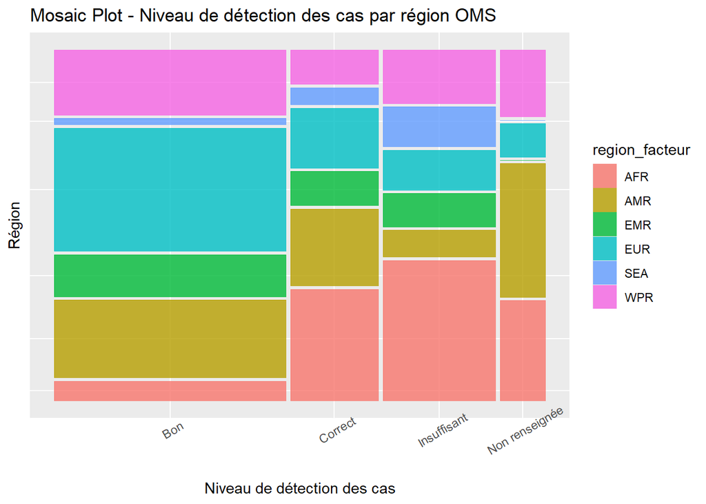

```r
# Créer le plot pour region_facteur et det_case
TB2_2000 %>%
  select(det_case, region_facteur) %>%
  ggplot() +
  geom_mosaic(aes(x = product(region_facteur, det_case), fill = region_facteur), na.rm = TRUE) +
  labs(y = "Région", x = "Niveau de détection des cas") +
  theme(axis.text.x = element_text(angle = 30)) +
  theme(axis.text.y = element_blank(), axis.ticks = element_blank()) +
  ggtitle("Mosaic Plot - Niveau de détection des cas par région OMS")
```

## khi-deux

```r
TB2%>%select(region_facteur,det_case) %>%table()%>%chisq.test()
```

```
##
##  Pearson's Chi-squared test
##
## data:  .
## X-squared = 1265.3, df = 15, p-value < 2.2e-16
```

#II.2.2)incidence & region_facteur

##Tableau de contingence

```r
# Créer le tableau de contingence pour incidence et region_facteur
contingence_inc_region <- TB2_2000 %>%
  select(incidence, region_facteur) %>%
  table()
# Calculer les fréquences conditionnelles pour la variable incidence par region_facteur
conditional_inc_region1 <- contingence_inc_region
conditional_inc_region2 <- contingence_inc_region

# Normalisation pour les colonnes (par région)
for(j in 1:ncol(conditional_inc_region1)) {
  conditional_inc_region1[,j] <- round(conditional_inc_region1[,j] / sum(conditional_inc_region1[,j]), digits = 2)
}

# Normalisation pour les lignes (par incidence)
for(i in 1:nrow(conditional_inc_region2)) {
  conditional_inc_region2[i,] <- round(conditional_inc_region2[i,] / sum(conditional_inc_region2[i,]), digits = 2)
}

#On veut s'assurer que 'n' est de type numérique avant de passer à tidy()
conditional_inc_region1_tidy <- broom::tidy(conditional_inc_region1) %>%
  mutate(n = as.numeric(n))  # Convertir 'n' en numérique si nécessaire
conditional_inc_region2_tidy <- broom::tidy(conditional_inc_region2) %>%
  mutate(n = as.numeric(n))  # Convertir 'n' en numérique si nécessaire
# Affichage du premier tableau (par colonnes)
conditional_inc_region1_tidy %>%
  tidyr::pivot_wider(names_from = region_facteur, values_from = n) %>%
  knitr::kable(format = "markdown", caption = "📊 Tableau de contingence normalisé pour `incidence` par `region_facteur` (normalisé par colonnes)")
```

📊 Tableau de contingence normalisé pour `incidence` par `region_facteur` (normalisé par colonnes)

| incidence | AFR | AMR | EMR | EUR | SEA | WPR |
| --- | --- | --- | --- | --- | --- | --- |
| 1 | 0.00 | 0.31 | 0.00 | 0.13 | 0.0 | 0.11 |
| 2 | 0.00 | 0.02 | 0.14 | 0.23 | 0.0 | 0.06 |
| 3 | 0.00 | 0.18 | 0.14 | 0.15 | 0.0 | 0.06 |
| 4 | 0.04 | 0.11 | 0.27 | 0.08 | 0.0 | 0.08 |
| 5 | 0.02 | 0.16 | 0.14 | 0.09 | 0.0 | 0.14 |
| 6 | 0.11 | 0.07 | 0.00 | 0.04 | 0.2 | 0.08 |
| 7 | 0.07 | 0.09 | 0.14 | 0.11 | 0.0 | 0.19 |
| 8 | 0.15 | 0.04 | 0.05 | 0.09 | 0.5 | 0.06 |
| 9 | 0.28 | 0.02 | 0.09 | 0.04 | 0.0 | 0.11 |
| 10 | 0.33 | 0.00 | 0.05 | 0.04 | 0.3 | 0.11 |

```r
# Affichage du deuxième tableau (par lignes)
conditional_inc_region2_tidy %>%
  tidyr::pivot_wider(names_from = region_facteur, values_from = n) %>%
  knitr::kable(format = "markdown", caption = "📊 Tableau de contingence normalisé pour `incidence` par `region_facteur` (normalisé par lignes)")
```

📊 Tableau de contingence normalisé pour `incidence` par `region_facteur` (normalisé par lignes)

| incidence | AFR | AMR | EMR | EUR | SEA | WPR |
| --- | --- | --- | --- | --- | --- | --- |
| 1 | 0.00 | 0.56 | 0.00 | 0.28 | 0.00 | 0.16 |
| 2 | 0.00 | 0.06 | 0.17 | 0.67 | 0.00 | 0.11 |
| 3 | 0.00 | 0.38 | 0.14 | 0.38 | 0.00 | 0.10 |
| 4 | 0.10 | 0.25 | 0.30 | 0.20 | 0.00 | 0.15 |
| 5 | 0.05 | 0.33 | 0.14 | 0.24 | 0.00 | 0.24 |
| 6 | 0.33 | 0.20 | 0.00 | 0.13 | 0.13 | 0.20 |
| 7 | 0.13 | 0.17 | 0.13 | 0.26 | 0.00 | 0.30 |
| 8 | 0.32 | 0.09 | 0.05 | 0.23 | 0.23 | 0.09 |
| 9 | 0.59 | 0.05 | 0.09 | 0.09 | 0.00 | 0.18 |
| 10 | 0.60 | 0.00 | 0.04 | 0.08 | 0.12 | 0.16 |

##mosaic plot

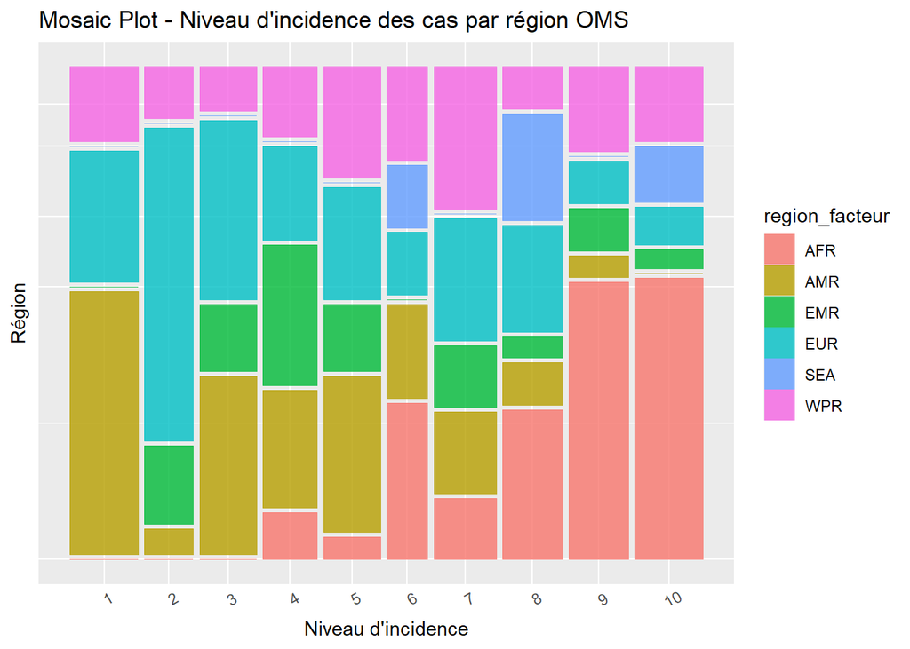

```r
# Créer le plot pour region_facteur et det_case
TB2_2000 %>%
  select(incidence, region_facteur) %>%
  ggplot() +
  geom_mosaic(aes(x = product(region_facteur, incidence), fill = region_facteur), na.rm = TRUE) +
  labs(y = "Région", x = "Niveau d'incidence") +
  theme(axis.text.x = element_text(angle = 30)) +
  theme(axis.text.y = element_blank(), axis.ticks = element_blank()) +
  ggtitle("Mosaic Plot - Niveau d'incidence des cas par région OMS")
```

## Khi deux

```r
TB2%>%select(region_facteur, incidence) %>%table()%>%chisq.test()
```

```
##
##  Pearson's Chi-squared test
##
## data:  .
## X-squared = 2705.4, df = 45, p-value < 2.2e-16
```

#II.2.3)det_case & prevalence ##Tableau de contingence

```r
# Créer le tableau de contingence pour det_case et prevalence
contingence_det_prevalence <- TB2_2000 %>%
  select(det_case, prevalence) %>%
  table()

# Calculer les fréquences conditionnelles pour la variable det_case par prevalence
conditional_det_prevalence1 <- contingence_det_prevalence
conditional_det_prevalence2 <- contingence_det_prevalence

# Normalisation pour les colonnes (par prévalence)
for(j in 1:ncol(conditional_det_prevalence1)) {
  conditional_det_prevalence1[,j] <- round(conditional_det_prevalence1[,j] / sum(conditional_det_prevalence1[,j]), digits = 2)
}

# Normalisation pour les lignes (par det_case)
for(i in 1:nrow(conditional_det_prevalence2)) {
  conditional_det_prevalence2[i,] <- round(conditional_det_prevalence2[i,] / sum(conditional_det_prevalence2[i,]), digits = 2)
}

# On veut s'assurer que 'n' est de type numérique avant de passer à tidy()
conditional_det_prevalence1_tidy <- broom::tidy(conditional_det_prevalence1) %>%
  mutate(n = as.numeric(n))  # Convertir 'n' en numérique si nécessaire
conditional_det_prevalence2_tidy <- broom::tidy(conditional_det_prevalence2) %>%
  mutate(n = as.numeric(n))  # Convertir 'n' en numérique si nécessaire
# Affichage du premier tableau (par colonnes)
conditional_det_prevalence1_tidy %>%
  tidyr::pivot_wider(names_from = prevalence, values_from = n) %>%
  knitr::kable(format = "markdown", caption = "📊 Tableau de contingence normalisé pour `det_case` par `prevalence` (normalisé par colonnes)")
```

📊 Tableau de contingence normalisé pour `det_case` par `prevalence` (normalisé par colonnes)

| det_case | 1 | 2 | 3 | 4 | 5 | 6 | 7 | 8 | 9 | 10 |
| --- | --- | --- | --- | --- | --- | --- | --- | --- | --- | --- |
| Bon | 0.67 | 0.86 | 0.89 | 0.76 | 0.70 | 0.44 | 0.39 | 0.19 | 0.07 | 0.04 |
| Correct | 0.05 | 0.00 | 0.00 | 0.19 | 0.22 | 0.19 | 0.43 | 0.31 | 0.14 | 0.29 |
| Insuffisant | 0.05 | 0.05 | 0.05 | 0.00 | 0.00 | 0.25 | 0.13 | 0.31 | 0.79 | 0.54 |
| Non renseignée | 0.24 | 0.10 | 0.05 | 0.05 | 0.09 | 0.12 | 0.04 | 0.19 | 0.00 | 0.12 |

```r
# Affichage du deuxième tableau (par lignes)
conditional_det_prevalence2_tidy %>%
  tidyr::pivot_wider(names_from = prevalence, values_from = n) %>%
  knitr::kable(format = "markdown", caption = "📊 Tableau de contingence normalisé pour `det_case` par `prevalence` (normalisé par lignes)")
```

📊 Tableau de contingence normalisé pour `det_case` par `prevalence` (normalisé par lignes)

| det_case | 1 | 2 | 3 | 4 | 5 | 6 | 7 | 8 | 9 | 10 |
| --- | --- | --- | --- | --- | --- | --- | --- | --- | --- | --- |
| Bon | 0.14 | 0.17 | 0.17 | 0.16 | 0.16 | 0.07 | 0.09 | 0.03 | 0.02 | 0.01 |
| Correct | 0.03 | 0.00 | 0.00 | 0.10 | 0.13 | 0.08 | 0.26 | 0.13 | 0.10 | 0.18 |
| Insuffisant | 0.02 | 0.02 | 0.02 | 0.00 | 0.00 | 0.08 | 0.06 | 0.10 | 0.44 | 0.26 |
| Non renseignée | 0.25 | 0.10 | 0.05 | 0.05 | 0.10 | 0.10 | 0.05 | 0.15 | 0.00 | 0.15 |

##mosaic plot

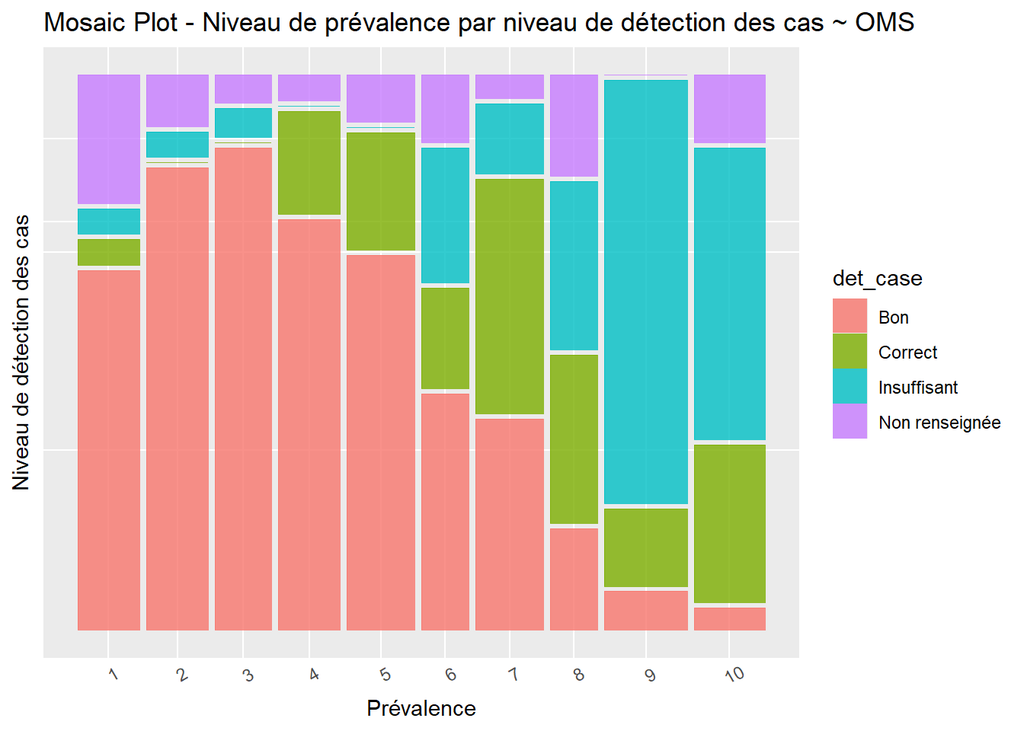

```r
# Créer le plot pour prevalence et det_case
TB2_2000 %>%
  select(det_case, prevalence) %>%
  ggplot() +
  geom_mosaic(aes(x = product(det_case,prevalence), fill = det_case), na.rm = TRUE) +
  labs(x = "Prévalence", y = "Niveau de détection des cas") +
  theme(axis.text.x = element_text(angle = 30)) +
  theme(axis.text.y = element_blank(), axis.ticks = element_blank()) +
  ggtitle("Mosaic Plot - Niveau de prévalence par niveau de détection des cas ~ OMS")
```

## Khi deux

```r
TB2%>%select(det_case, prevalence) %>%table()%>%chisq.test()
```

```
##
##  Pearson's Chi-squared test
##
## data:  .
## X-squared = 2218.3, df = 27, p-value < 2.2e-16
```

```r
#p-value très petit on rejette théorie de d'indépendance et on conclut à la dépendance entre det_case et prevalence
```

#II.C) Analyse bivariée quantitative et qualitative #II.3.1)region & mortalité sans VIH

##boxplot

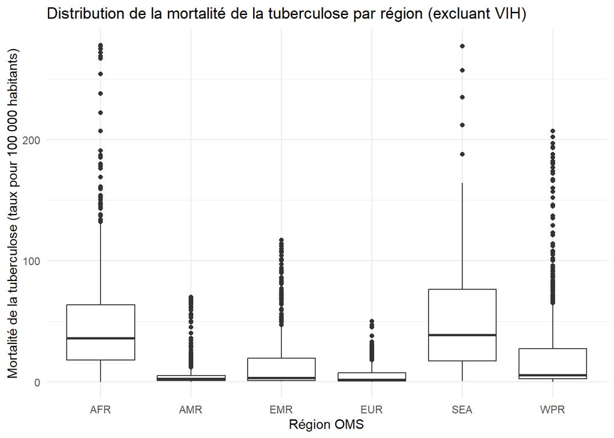

```r
# Créer un boxplot pour visualiser la distribution de la mortalité de la tuberculose par région
ggplot(TB2, aes(x = region_facteur, y = `Estimated_mortality_of_TB_cases_(all_forms,_excluding_HIV)_per_100_000_population`)) +
  geom_boxplot() +
  ggtitle("Distribution de la mortalité de la tuberculose par région (excluant VIH)") +
  xlab("Région OMS") +
  ylab("Mortalité de la tuberculose (taux pour 100 000 habitants)") +
  theme_minimal()
```

##rapport de corélation

```r
# Calcul du rapport de corrélation avec eta2 (entre 'region_facteur' et 'Estimated_mortality_EXVIH_of_TB')
eta2(TB2$`Estimated_mortality_of_TB_cases_(all_forms,_excluding_HIV)_per_100_000_population`,TB2$region_facteur)  # rapport de corrélation
```

```
## [1] 0.2830339
```

```r
# Créer le modèle linéaire pour tester l'effet de 'det_case' sur la prévalence estimée
lm_result <- summary(lm(TB2$`Estimated_mortality_of_TB_cases_(all_forms,_excluding_HIV)_per_100_000_population` ~ TB2$region_facteur))

# Afficher les résultats du modèle
print(lm_result)
```

```
##
## Call:
## lm(formula = TB2$`Estimated_mortality_of_TB_cases_(all_forms,_excluding_HIV)_per_100_000_population` ~
##     TB2$region_facteur)
##
## Residuals:
##     Min      1Q  Median      3Q     Max
## -53.245 -14.908  -4.114   3.181 232.110
##
## Coefficients:
##                       Estimate Std. Error t value Pr(>|t|)
## (Intercept)            45.8905     0.8375  54.792  < 2e-16 ***
## TB2$region_facteurAMR -41.0318     1.1896 -34.492  < 2e-16 ***
## TB2$region_facteurEMR -29.1392     1.4738 -19.771  < 2e-16 ***
## TB2$region_facteurEUR -40.7518     1.1435 -35.637  < 2e-16 ***
## TB2$region_facteurSEA   7.8444     1.9450   4.033 5.58e-05 ***
## TB2$region_facteurWPR -24.7822     1.2650 -19.591  < 2e-16 ***
## ---
## Signif. codes:  0 '***' 0.001 '**' 0.01 '*' 0.05 '.' 0.1 ' ' 1
##
## Residual standard error: 27.87 on 5114 degrees of freedom
## Multiple R-squared:  0.283,  Adjusted R-squared:  0.2823
## F-statistic: 403.8 on 5 and 5114 DF,  p-value: < 2.2e-16
```

#II.3.2)region & mortalité avec VIH

## boxplot

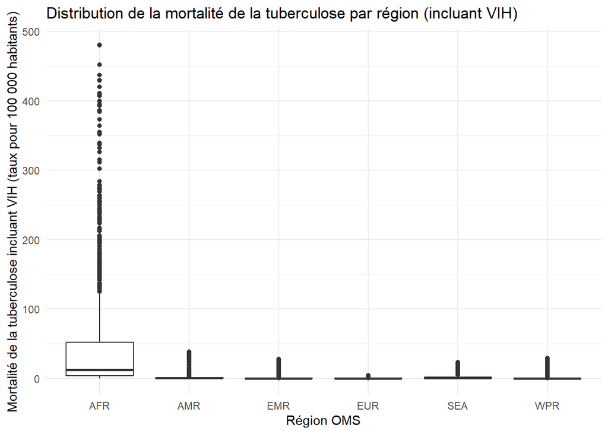

```r
# Créer un boxplot pour visualiser la distribution de la mortalité de la tuberculose incluant VIH par région
ggplot(TB2, aes(x = region_facteur, y = `Estimated_mortality_of_TB_cases_who_are_HIV-positive,_per_100_000_population`)) +
  geom_boxplot() +
  ggtitle("Distribution de la mortalité de la tuberculose par région (incluant VIH)") +
  xlab("Région OMS") +
  ylab("Mortalité de la tuberculose incluant VIH (taux pour 100 000 habitants)") +
  theme_minimal()
```

## rapport de corrélation

```r
# Calcul du rapport de corrélation avec eta2 (entre 'region_facteur' et 'Estimated_mortality_of_TB')
eta2(TB2$`Estimated_mortality_of_TB_cases_who_are_HIV-positive,_per_100_000_population`,TB2$region_facteur)  # rapport de corrélation
```

```
## [1] 0.2080755
```

```r
# Créer le modèle linéaire pour tester l'effet de 'det_case' sur la prévalence estimée
lm_result <- summary(lm(TB2$`Estimated_mortality_of_TB_cases_who_are_HIV-positive,_per_100_000_population` ~ TB2$region_facteur))

# Afficher les résultats du modèle
print(lm_result)
```

```
##
## Call:
## lm(formula = TB2$`Estimated_mortality_of_TB_cases_who_are_HIV-positive,_per_100_000_population` ~
##     TB2$region_facteur)
##
## Residuals:
##    Min     1Q Median     3Q    Max
## -51.27  -1.51  -0.82  -0.21 429.73
##
## Coefficients:
##                       Estimate Std. Error t value Pr(>|t|)
## (Intercept)             51.271      1.216   42.17   <2e-16 ***
## TB2$region_facteurAMR  -49.766      1.727  -28.82   <2e-16 ***
## TB2$region_facteurEMR  -50.372      2.140  -23.54   <2e-16 ***
## TB2$region_facteurEUR  -51.034      1.660  -30.74   <2e-16 ***
## TB2$region_facteurSEA  -48.571      2.824  -17.20   <2e-16 ***
## TB2$region_facteurWPR  -50.448      1.836  -27.47   <2e-16 ***
## ---
## Signif. codes:  0 '***' 0.001 '**' 0.01 '*' 0.05 '.' 0.1 ' ' 1
##
## Residual standard error: 40.45 on 5114 degrees of freedom
## Multiple R-squared:  0.2081, Adjusted R-squared:  0.2073
## F-statistic: 268.7 on 5 and 5114 DF,  p-value: < 2.2e-16
```

#II.3.3)det_case & estimated prévalence

# Créer un boxplot pour visualiser la distribution de la prévalence estimée par niveau de détection des cas

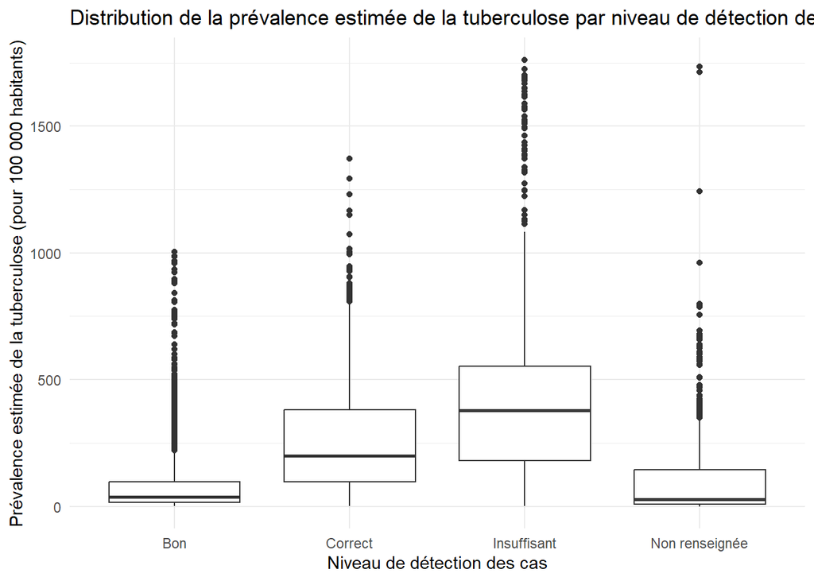

```r
ggplot(TB2, aes(x = det_case, y = `Estimated_prevalence_of_TB_(all_forms)_per_100_000_population`)) +
  geom_boxplot() +
  ggtitle("Distribution de la prévalence estimée de la tuberculose par niveau de détection des cas") +
  xlab("Niveau de détection des cas") +
  ylab("Prévalence estimée de la tuberculose (pour 100 000 habitants)") +
  theme_minimal()
```

##rapport de corrélation

```r
# Calcul du rapport de corrélation avec eta2 (entre 'det_case' et 'Estimated_prevalence_of_TB')
eta2(TB2$`Estimated_prevalence_of_TB_(all_forms)_per_100_000_population`,TB2$det_case)  # rapport de corrélation
```

```
## [1] 0.2836523
```

```r
# Créer le modèle linéaire pour tester l'effet de 'det_case' sur la prévalence estimée
lm_result <- summary(lm(TB2$`Estimated_prevalence_of_TB_(all_forms)_per_100_000_population` ~ TB2$det_case))

# Afficher les résultats du modèle
print(lm_result)
```

```
##
## Call:
## lm(formula = TB2$`Estimated_prevalence_of_TB_(all_forms)_per_100_000_population` ~
##     TB2$det_case)
##
## Residuals:
##     Min      1Q  Median      3Q     Max
## -428.96  -79.14  -52.26   43.74 1603.87
##
## Coefficients:
##                            Estimate Std. Error t value Pr(>|t|)
## (Intercept)                  84.263      4.268  19.743  < 2e-16 ***
## TB2$det_caseCorrect         181.775      8.215  22.127  < 2e-16 ***
## TB2$det_caseInsuffisant     345.900      7.987  43.307  < 2e-16 ***
## TB2$det_caseNon renseignée   47.866     11.194   4.276 1.94e-05 ***
## ---
## Signif. codes:  0 '***' 0.001 '**' 0.01 '*' 0.05 '.' 0.1 ' ' 1
##
## Residual standard error: 219.3 on 5116 degrees of freedom
## Multiple R-squared:  0.2837, Adjusted R-squared:  0.2832
## F-statistic: 675.3 on 3 and 5116 DF,  p-value: < 2.2e-16
```

# III) ACP2

```r
TB2_2000_ACP<-TB2_2000%>%
  select( Country=Country_or_territory_name,
          `ISO_3-character_country/territory_code`,
          Region,
          Year,
          Estimated_prevalence =`Estimated_prevalence_of_TB_(all_forms)_per_100_000_population`,
         Mortalite_sans_VIH= `Estimated_mortality_of_TB_cases_(all_forms,_excluding_HIV)_per_100_000_population`,
          Mortalite_avec_VIH= `Estimated_mortality_of_TB_cases_who_are_HIV-positive,_per_100_000_population` ,
         Estimated_incidence =`Estimated_incidence_(all_forms)_per_100_000_population`,Method_to_derive_mortality_estimates, Method_to_derive_prevalence_estimates ,`Case_detection_rate_(all_forms),_percent`,  region_facteur ,  det_case        , incidence, prevalence
         )
```

```r
head(TB2_2000_ACP)
```

```
## # A tibble: 6 × 15
##   Country        ISO_3-character_country/ter…¹ Region  Year Estimated_prevalence
##   <chr>          <chr>                         <chr>  <dbl>                <dbl>
## 1 Afghanistan    AFG                           EMR     2000                430
## 2 Albania        ALB                           EUR     2000                 30
## 3 Algeria        DZA                           AFR     2000                129
## 4 American Samoa ASM                           WPR     2000                  9.3
## 5 Andorra        AND                           EUR     2000                 31
## 6 Angola         AGO                           AFR     2000                395
## # ℹ abbreviated name: ¹`ISO_3-character_country/territory_code`
## # ℹ 10 more variables: Mortalite_sans_VIH <dbl>, Mortalite_avec_VIH <dbl>,
## #   Estimated_incidence <dbl>, Method_to_derive_mortality_estimates <chr>,
## #   Method_to_derive_prevalence_estimates <chr>,
## #   `Case_detection_rate_(all_forms),_percent` <dbl>, region_facteur <fct>,
## #   det_case <chr>, incidence <fct>, prevalence <fct>
```

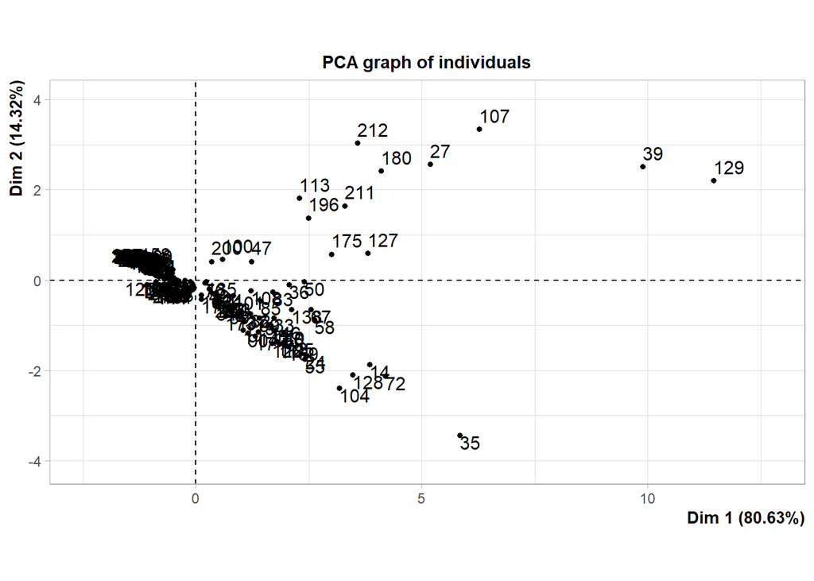

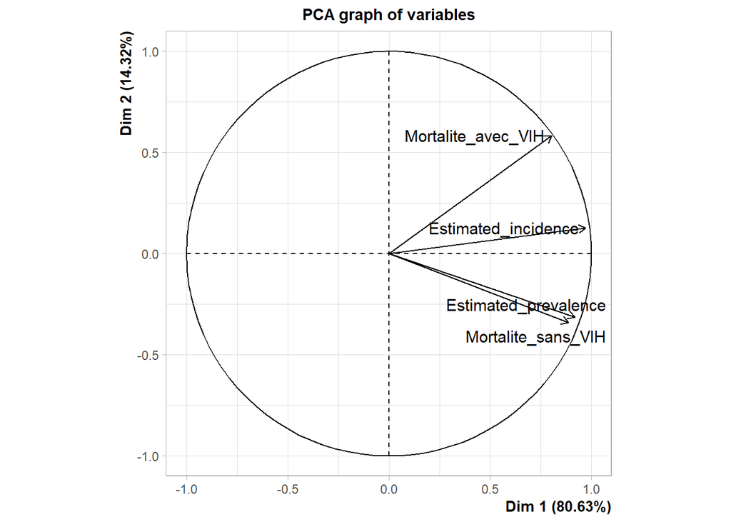

```r
res.pca =PCA(TB2_2000_ACP[,5:8],scale.unit = TRUE, graph=T)
```

```r
knitr::kable(factoextra::get_eig(res.pca))
```

|  | eigenvalue | variance.percent | cumulative.variance.percent |
| --- | --- | --- | --- |
| Dim.1 | 3.2252327 | 80.6308185 | 80.63082 |
| Dim.2 | 0.5729499 | 14.3237473 | 94.95457 |
| Dim.3 | 0.1739988 | 4.3499701 | 99.30454 |
| Dim.4 | 0.0278186 | 0.6954642 | 100.00000 |

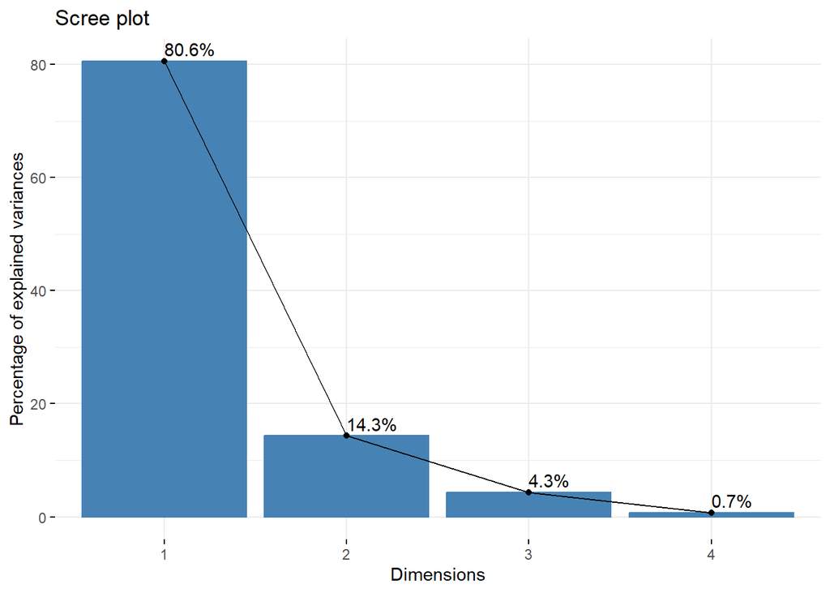

```r
fviz_screeplot(res.pca,addlabels=TRUE)
```

```r
res.pca
```

```
## **Results for the Principal Component Analysis (PCA)**
## The analysis was performed on 212 individuals, described by 4 variables
## *The results are available in the following objects:
##
##    name               description
## 1  "$eig"             "eigenvalues"
## 2  "$var"             "results for the variables"
## 3  "$var$coord"       "coord. for the variables"
## 4  "$var$cor"         "correlations variables - dimensions"
## 5  "$var$cos2"        "cos2 for the variables"
## 6  "$var$contrib"     "contributions of the variables"
## 7  "$ind"             "results for the individuals"
## 8  "$ind$coord"       "coord. for the individuals"
## 9  "$ind$cos2"        "cos2 for the individuals"
## 10 "$ind$contrib"     "contributions of the individuals"
## 11 "$call"            "summary statistics"
## 12 "$call$centre"     "mean of the variables"
## 13 "$call$ecart.type" "standard error of the variables"
## 14 "$call$row.w"      "weights for the individuals"
## 15 "$call$col.w"      "weights for the variables"
```

```r
kable(res.pca$var$contrib)
```

|  | Dim.1 | Dim.2 | Dim.3 | Dim.4 |
| --- | --- | --- | --- | --- |
| Estimated_prevalence | 26.21807 | 17.259275 | 27.223631 | 29.299028 |
| Mortalite_sans_VIH | 24.45108 | 20.456519 | 53.950035 | 1.142367 |
| Mortalite_avec_VIH | 20.02936 | 59.437241 | 5.300789 | 15.232606 |
| Estimated_incidence | 29.30149 | 2.846965 | 13.525545 | 54.325998 |

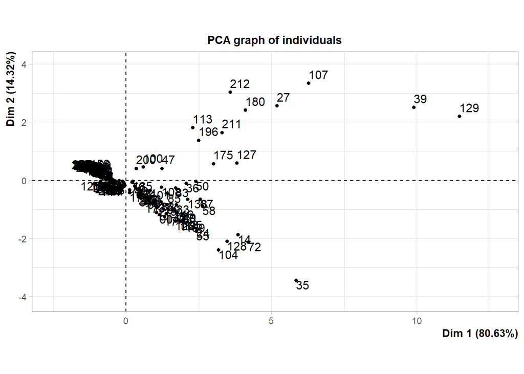

```r
plot.PCA(res.pca, aes=c(1,2), choix="ind")
```

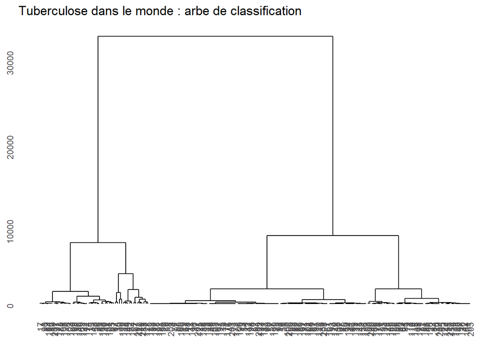

```r
matrice.region<-dist(TB2_2000_ACP[,5:8])
tb.clust<-hclust(matrice.region, method="ward.D")
ggdendrogram(tb.clust, rotate = FALSE, size=2)+
  labs(title = "Tuberculose dans le monde : arbe de classification")
```